# FIESTA - Data Tools

## FIESTA Overview

The R package, FIESTA (Forest Inventory ESTimation and Analysis) is a research estimation tool for analysts that work with sample-based inventory data like that from the U.S. Department of Agriculture, Forest Service, Forest Inventory and Analysis (FIA) Program to accommodate: unique population boundaries, different evaluation time periods, customized stratification schemes, non-standard variance equations, integration of multi-scale remotely-sensed data and other ancillary information, and interaction with other modeling and estimation tools from CRAN R’s library of packages. FIESTA contains a collection of functions that can access FIA databases, summarize and compile plot and spatial data, and generate estimates with associated sampling errors.

Functions are organized by type or objective and are named with a corresponding prefix:

**Core Functions**

- Database tools (DB) - functions for querying and extracting data from FIA’s national database.
- Data tools (dat) - functions for summarizing and exploring FIA data.
- Spatial tools (sp) - functions for manipulating and summarizing spatial data.

**Estimation Modules**

- Green-Book (GB) - functions for FIA’s standard ‘Green-Book’ estimators.
- Photo-Based (PB) - functions for supplementary photo-based estimators.
- Small Area (SA) - functions for integration with available small area estimators (SAE).
- Model-Assisted (MA) - functions for integration with available Model-Assisted estimators.

**Analysis Tools**

- Analysis tools (an) - wrapper functions for stream-lining estimation processes.

### Overview of FIESTA data (dat) tools

FIESTA’s dat tools assist with customizing variables as well as summarizing and visualizing FIA data. The datLUTclass and datLUTnm functions help with merging look-up tables to support new variables, standard FIA code names or unique names, or groupings of discrete or continuous data values. The datSum* functions provide tools for aggregating FIA data for estimation, mapping, or exploratory data analyses.

### Objective of tutorial

| FUNCTION | DESCRIPTION |
| --- | --- |
| datFilter() | Subsets a data table by specified filter(s). |
| datFreq() | Generates frequency table. |
| datPivot() | Generates pivot table. |
| datBarplot() | Generates bar plot. |
| datBarplotStacked() | Generates stacked bar plot. |
| datPiechart() | Generates pie chart. |
| datLUTclass() | Merge look-up table for classifying continuous data (e.g., DIA). |
| datLUTnm() | Merge look-up table to append names or categories. |
| datSumCond() | Aggregates numeric condition data to plot level. |
| datSumTree() | Aggregates numeric tree data to the plot or condition-level. |
| datSumTreeDom() | Aggregates numeric tree data by tree domain to plot or condition level. |

### Set up

We just load the `FIESTA` library to get started with the examples.

```r
# Load library
library(FIESTA)
```

The following examples use FIA data from Wyoming for inventory years 2011-2013.

### `datFilter()`

The `datFilter` function subsets a data table by specified filter(s) or logical statement and returns a list of the filtered data table and the filter.

#### Example 1: Subset National Forest Conditions in Wyoming

**View Example**

```r
WYconddat.nfs <- datFilter(
        x = WYcond,
        xfilter = "ADFORCD > 0"
        )

names(WYconddat.nfs)
```

**output**

```
## [1] "xf"      "xfilter"
```

```r
WYcond.nfs <- WYconddat.nfs$xf
dim(WYcond.nfs)
```

**output**

```
## [1] 552  26
```

```r
head(WYcond.nfs)
```

**output**

```
##            PLT_CN CONDID COND_NONSAMPLE_REASN_CD CONDPROP_UNADJ SUBPPROP_UNADJ
## 1: 40404730010690      1                      NA           1.00           1.00
## 2: 40404737010690      1                      NA           0.75           0.75
## 3: 40404737010690      2                      NA           0.25           0.25
## 4: 40404742010690      1                      NA           1.00           1.00
## 5: 40404818010690      1                      NA           1.00           1.00
## 6: 40404821010690      1                      NA           1.00           1.00
##    MICRPROP_UNADJ MACRPROP_UNADJ OWNCD OWNGRPCD RESERVCD SITECLCD STDORGCD
## 1:           1.00             NA    11       10        0        6        0
## 2:           0.75             NA    11       10        0       NA       NA
## 3:           0.25             NA    11       10        0        7        0
## 4:           1.00             NA    11       10        0        6        0
## 5:           1.00             NA    11       10        0       NA       NA
## 6:           1.00             NA    11       10        0        5        0
##    ADFORCD LIVE_CANOPY_CVR_PCT COND_STATUS_CD NF_COND_STATUS_CD FORTYPCD
```

[output cut: 20 more lines]

#### Example 2: Subset Trees That Are Standing Dead Aspen Trees in Wyoming

**View Example**

```r
WYtreedat.dead <- datFilter(
        x = WYtree,
        xfilter = "STATUSCD == 2 & STANDING_DEAD_CD == 1 & SPCD == 746"
        )

names(WYtreedat.dead)
```

**output**

```
## [1] "xf"      "xfilter"
```

```r
WYtree.deadasp <- WYtreedat.dead$xf
head(WYtree.deadasp)
```

**output**

```
##            PLT_CN CONDID SUBP TREE STATUSCD SPCD SPGRPCD  DIA HT TREECLCD
## 1: 40404831010690      1    4    1        2  746      44  5.6 14        3
## 2: 40404843010690      1    4    2        2  746      44  7.9 29        3
## 3: 40404920010690      1    1    2        2  746      44  7.4 44        3
## 4: 40404920010690      1    1   16        2  746      44  8.5 38        3
## 5: 40404920010690      1    2    1        2  746      44  8.9 42        3
## 6: 40404920010690      1    2   11        2  746      44 10.3 40        4
##    AGENTCD STANDING_DEAD_CD VOLCFNET VOLCFGRS VOLBFNET TPA_UNADJ  DRYBIO_AG
## 1:      20                1 0.042070 0.056093       NA  6.018046   0.679523
## 2:      70                1 2.329483 3.065109       NA  6.018046  35.836056
## 3:      20                1 4.074443 4.381121       NA  6.018046  98.156004
## 4:      NA                1 4.811647 5.118773       NA  6.018046 113.345699
## 5:      20                1 6.138979 6.394770       NA  6.018046 143.636088
## 6:      NA                1 0.000000 8.407102       NA  6.018046 119.261221
##    CARBON_AG        BA
## 1:  0.339762 0.1710374
## 2: 17.918028 0.3403841
## 3: 49.078002 0.2986610
## 4: 56.672850 0.3940515
## 5: 71.818044 0.4320113
## 6: 59.630611 0.5786149
```

```r
dim(WYtree.deadasp)
```

**output**

```
## [1] 211  19
```

```r
dim(WYtree)
```

**output**

```
## [1] 18380    19
```

#### Example 3: Subset Trees That Are Standing Dead Aspens in Wyoming, and Subset Other Tables to Match

**View Example**

```r
WYtreedat.dead2 <- datFilter(
        x = WYtree,
        xfilter = "STATUSCD == 2 & STANDING_DEAD_CD == 1 & SPCD == 746",
        othertabnms = c("WYplt", "WYcond")
        )

names(WYtreedat.dead2)
```

**output**

```
## [1] "xf"       "xfilter"  "cliptabs"
```

```r
WYtree.deadasp2 <- WYtreedat.dead2$xf
head(WYtree.deadasp2)
```

**output**

```
##            PLT_CN CONDID SUBP TREE STATUSCD SPCD SPGRPCD  DIA HT TREECLCD
## 1: 40404831010690      1    4    1        2  746      44  5.6 14        3
## 2: 40404843010690      1    4    2        2  746      44  7.9 29        3
## 3: 40404920010690      1    1    2        2  746      44  7.4 44        3
## 4: 40404920010690      1    1   16        2  746      44  8.5 38        3
## 5: 40404920010690      1    2    1        2  746      44  8.9 42        3
## 6: 40404920010690      1    2   11        2  746      44 10.3 40        4
##    AGENTCD STANDING_DEAD_CD VOLCFNET VOLCFGRS VOLBFNET TPA_UNADJ  DRYBIO_AG
## 1:      20                1 0.042070 0.056093       NA  6.018046   0.679523
## 2:      70                1 2.329483 3.065109       NA  6.018046  35.836056
## 3:      20                1 4.074443 4.381121       NA  6.018046  98.156004
## 4:      NA                1 4.811647 5.118773       NA  6.018046 113.345699
## 5:      20                1 6.138979 6.394770       NA  6.018046 143.636088
## 6:      NA                1 0.000000 8.407102       NA  6.018046 119.261221
##    CARBON_AG        BA
## 1:  0.339762 0.1710374
## 2: 17.918028 0.3403841
## 3: 49.078002 0.2986610
## 4: 56.672850 0.3940515
## 5: 71.818044 0.4320113
## 6: 59.630611 0.5786149
```

```r
dim(WYtree.deadasp2)
```

**output**

```
## [1] 211  19
```

```r
WYtree.deadasptabs <- WYtreedat.dead2$cliptabs
names(WYtree.deadasptabs)
```

**output**

```
## [1] "clip_WYplt"  "clip_WYcond"
```

```r
WYplt.deadasp <- WYtree.deadasptabs$clip_WYplt
WYcond.deadasp <- WYtree.deadasptabs$clip_WYcond

dim(WYplt.deadasp)
```

**output**

```
## [1] 40 20
```

```r
dim(WYcond.deadasp)
```

**output**

```
## [1] 56 26
```

### `datFreq()`

The `datFreq` function generates a frequency table from a data frame, including number of records by a specified variable or variables in the data frame with optional totals and/or subtotals.

#### Example: Multiple Uses

**View Example**

```r
## Get number of plots by county
datFreq(
      x = WYplt,
      xvar="COUNTYCD"
      )
```

**output**

```
##    COUNTYCD FREQ
## 1         1  133
## 2         3   98
## 3         5  152
## 4         7  245
## 5         9  133
## 6        11   85
## 7        13  290
## 8        15   70
## 9        17   58
## 10       19  128
## 11       21   86
## 12       23  132
## 13       25  175
## 14       27   79
## 15       29  216
## 16       31   64
## 17       33   82
## 18       35  158
## 19       37  339
## 20       39  125
## 21       41   63
## 22       43   63
## 23       45   73
```

```r
## Get number of plots by county and plot status
datFreq(
      x = WYplt,
      xvar=c("COUNTYCD", "PLOT_STATUS_CD")
      )
```

**output**

```
##    COUNTYCD PLOT_STATUS_CD FREQ
## 1         1              1   24
## 2         1              2  109
## 3         3              1   12
## 4         3              2   86
## 5         5              1   14
## 6         5              2  138
## 7         7              1   36
## 8         7              2  209
## 9         9              1   18
## 10        9              2  115
## 11       11              1   26
## 12       11              2   59
## 13       13              1   53
## 14       13              2  237
```

[output cut: 32 more lines]

```r
## Get number of plots by county and plot status with subtotals
datFreq(
      x = WYplt,
      xvar = c("COUNTYCD", "PLOT_STATUS_CD"),
      subtotal = TRUE
      )
```

**output**

```
##     COUNTYCD PLOT_STATUS_CD FREQ
## 1          1              1   24
## 3          3              1   12
## 5          5              1   14
## 7          7              1   36
## 9          9              1   18
## 11        11              1   26
## 13        13              1   53
## 15        15              1    2
## 17        17              1    8
## 19        19              1   22
## 21        21              1    2
## 23        23              1   38
## 25        25              1    7
## 27        27              1    2
```

[output cut: 34 more lines]

```r
## Get number of plots by county and plot status with subtotals
datFreq(
      x = WYplt,
      xvar = c("COUNTYCD", "PLOT_STATUS_CD"),
      subtotal = TRUE,
      subtotalcol = "COUNTYCD"
      )
```

**output**

```
##     COUNTYCD PLOT_STATUS_CD FREQ
## 1          1              1   24
## 2          1              2  109
## 3                  Subtotal  133
## 31         3              1   12
## 4          3              2   86
## 6                  Subtotal   98
## 5          5              1   14
## 61         5              2  138
## 9                  Subtotal  152
## 7          7              1   36
## 8          7              2  209
## 12                 Subtotal  245
## 91         9              1   18
## 10         9              2  115
```

[output cut: 55 more lines]

### `datPivot()`

The `datPivot` function generates a pivot table.

#### Example: Multiple Uses

**View Example**

```r
## Get summed condition proportions by forest type class and stand size class
datPivot(
      x = WYcond,
      pvar = "CONDPROP_UNADJ",
      xvar = "FORTYPCD",
      yvar = "STDSZCD"
      )
```

**output**

```
##     FORTYPCD     1     2     3     5
##  1:      182 23.23  3.00  4.50  0.00
##  2:      184 15.50  0.00  1.00  0.00
##  3:      185  0.75  0.00  0.00  0.00
##  4:      201 27.85  5.50  8.50  0.00
##  5:      221 39.97  2.25  2.75  0.00
##  6:      265 16.25  3.25  3.25  0.00
##  7:      266 48.25 12.51 10.50  0.00
##  8:      268 28.38  7.50  9.49  0.00
##  9:      269  1.00  0.00  0.00  0.00
## 10:      281 43.95 39.43 34.68  0.00
## 11:      366  3.50  0.00  7.59  0.00
## 12:      367  4.37  5.75  7.50  0.00
## 13:      509  1.00  1.75  2.00  0.00
## 14:      517  0.00  0.00  1.00  0.00
## 15:      703  3.03  0.25  1.00  0.00
## 16:      706  0.00  0.50  0.00  0.00
## 17:      901  2.00  8.12 19.25  0.00
## 18:      999  0.00  0.00  0.00 40.75
```

```r
## Get average height by species group code and status code
datPivot(
      x = WYtree,
      pvar = "HT",
      xvar = "SPGRPCD",
      yvar = "TREECLCD",
      pfun = mean
      )
```

**output**

```
##     SPGRPCD     2     3     4
##  1:      10 46.28 50.86 68.00
##  2:      11 39.71 32.64 54.54
##  3:      12 41.68 45.98 57.22
##  4:      18 47.15 59.76 66.70
##  5:      21 44.84 52.95 56.60
##  6:      23  0.00 11.67 10.00
##  7:      24 29.78 35.39 35.38
##  8:      44 37.61 35.57 41.47
##  9:      47 26.82 28.13 39.50
## 10:      48  0.00 12.20  0.00
```

### `datLUTclass()`

The `datLUTclass` function merges a look-up table to define categories of continuous data in `x` (e.g., `DIACL`). Adds a variable to `x`, setting the variable to `VARCLNM` where: `xvar >= MIN` and `xvar < MAX`.

#### Example 1: Reference Table Stored in `FIESTA` with 2-inch Diameter Classes

**View Example**

```r
ref_diacl2in
```

**output**

```
##    MIN  MAX  DIACL2IN
## 1    1  2.9   1.0-2.9
## 2    3  4.9   3.0-4.9
## 3    5  6.9   5.0-6.9
## 4    7  8.9   7.0-8.9
## 5    9 10.9  9.0-10.9
## 6   11 12.9 11.0-12.9
## 7   13 14.9 13.0-14.9
## 8   15 16.9 15.0-16.9
## 9   17 18.9 17.0-18.9
## 10  19 20.9 19.0-20.9
## 11  21 22.9 21.0-22.9
## 12  23 24.9 23.0-24.9
## 13  25 26.9 25.0-26.9
## 14  27 28.9 27.0-28.9
```

[output cut: 26 more lines]

```r
WYtreelut <- datLUTclass(
                x = WYtree,
                xvar = "DIA",
                LUT = ref_diacl2in,
                LUTclassnm = "DIACL2IN"
                )

names(WYtreelut)
```

**output**

```
## [1] "xLUT"       "LUTclassnm" "LUT"
```

```r
WYtree2 <- WYtreelut$xLUT
head(WYtree2)
```

**output**

```
##           PLT_CN CONDID SUBP TREE STATUSCD SPCD SPGRPCD DIA HT TREECLCD AGENTCD
## 1 40404738010690      1    2    3        2   19      12  NA NA       NA      70
## 2 40404738010690      1    2    4        2   19      12  NA NA       NA      70
## 3 40404738010690      1    2    7        1   19      12 5.3 26        2      NA
## 4 40404821010690      1    1    7        1   19      12 5.9 48        2      NA
## 5 40404821010690      1    1    8        1   19      12 8.1 45        2      NA
## 6 40404821010690      1    1   11        2   19      12  NA NA       NA      70
##   STANDING_DEAD_CD VOLCFNET VOLCFGRS VOLBFNET TPA_UNADJ DRYBIO_AG CARBON_AG
## 1                0       NA       NA       NA        NA   0.00000        NA
## 2                0       NA       NA       NA        NA   0.00000        NA
## 3               NA 0.864289 0.864289       NA  6.018046  25.48605  12.74303
## 4               NA 3.046342 3.046342       NA  6.018046  88.91319  44.45660
## 5               NA 6.019584 6.019584       NA  6.018046 171.35480  85.67740
## 6                0       NA       NA       NA        NA   0.00000        NA
##          BA DIACL2IN
## 1        NA     <NA>
## 2        NA     <NA>
## 3 0.1532029  5.0-6.9
## 4 0.1898537  5.0-6.9
## 5 0.3578369  7.0-8.9
## 6        NA     <NA>
```

```r
dim(WYtree)
```

**output**

```
## [1] 18380    19
```

```r
dim(WYtree2)
```

**output**

```
## [1] 18380    20
```

#### Example 2: Create New Reference Table and Merge to Tree Table

**View Example**

```r
diacl25 <- data.frame(
              MIN = c(5,25),
              MAX = c(25, 100),
              DIACL25 = c("5.0-24.9", "25.0+" )
              )
diacl25
```

**output**

```
##   MIN MAX  DIACL25
## 1   5  25 5.0-24.9
## 2  25 100    25.0+
```

```r
WYtreelut2 <- datLUTclass(
                  x = WYtree,
                  xvar = "DIA",
                  LUT = diacl25,
                  LUTclassnm = "DIACL25"
                  )

names(WYtreelut2)
```

**output**

```
## [1] "xLUT"       "LUTclassnm" "LUT"
```

```r
WYtree2 <- WYtreelut2$xLUT
head(WYtree2)
```

**output**

```
##           PLT_CN CONDID SUBP TREE STATUSCD SPCD SPGRPCD DIA HT TREECLCD AGENTCD
## 1 40404738010690      1    2    3        2   19      12  NA NA       NA      70
## 2 40404738010690      1    2    4        2   19      12  NA NA       NA      70
## 3 40404738010690      1    2    7        1   19      12 5.3 26        2      NA
## 4 40404821010690      1    1    7        1   19      12 5.9 48        2      NA
## 5 40404821010690      1    1    8        1   19      12 8.1 45        2      NA
## 6 40404821010690      1    1   11        2   19      12  NA NA       NA      70
##   STANDING_DEAD_CD VOLCFNET VOLCFGRS VOLBFNET TPA_UNADJ DRYBIO_AG CARBON_AG
## 1                0       NA       NA       NA        NA   0.00000        NA
## 2                0       NA       NA       NA        NA   0.00000        NA
## 3               NA 0.864289 0.864289       NA  6.018046  25.48605  12.74303
## 4               NA 3.046342 3.046342       NA  6.018046  88.91319  44.45660
## 5               NA 6.019584 6.019584       NA  6.018046 171.35480  85.67740
## 6                0       NA       NA       NA        NA   0.00000        NA
##          BA  DIACL25
## 1        NA     <NA>
## 2        NA     <NA>
## 3 0.1532029 5.0-24.9
## 4 0.1898537 5.0-24.9
## 5 0.3578369 5.0-24.9
## 6        NA     <NA>
```

```r
dim(WYtree)
```

**output**

```
## [1] 18380    19
```

```r
dim(WYtree2)
```

**output**

```
## [1] 18380    20
```

#### Example 3: Use Cutbreaks to Classify `LIVE_CANOPY_CVR_PCT` variable from `WYcond` Table

**View Example**

```r
cutbreaks <- c(0,25,50,100)
WYcondlut <- datLUTclass(
                x = WYcond,
                xvar = "LIVE_CANOPY_CVR_PCT",
                cutbreaks = cutbreaks
                )

names(WYcondlut)
```

**output**

```
## [1] "xLUT"       "LUTclassnm" "LUT"
```

```r
head(WYcondlut$xLUT)
```

**output**

```
##           PLT_CN CONDID COND_NONSAMPLE_REASN_CD CONDPROP_UNADJ SUBPPROP_UNADJ
## 1 40404728010690      1                      NA              1              1
## 2 40404729010690      1                      NA              1              1
## 3 40404730010690      1                      NA              1              1
## 4 40404731010690      1                      NA              1              1
## 5 40404733010690      1                      NA              1              1
## 6 40404734010690      1                      NA              1              1
##   MICRPROP_UNADJ MACRPROP_UNADJ OWNCD OWNGRPCD RESERVCD SITECLCD STDORGCD
## 1              1             NA    46       40        0       NA       NA
## 2              1             NA    46       40        0        7        0
## 3              1             NA    11       10        0        6        0
## 4              1             NA    22       20        0       NA       NA
## 5              1             NA    46       40        0       NA       NA
## 6              1             NA    22       20        0       NA       NA
##   ADFORCD LIVE_CANOPY_CVR_PCT COND_STATUS_CD NF_COND_STATUS_CD FORTYPCD STDSZCD
```

[output cut: 20 more lines]

```r
WYcondlut$LUT
```

**output**

```
##    LIVE_CANOPY_CVR_PCT_cutbreaks LIVE_CANOPY_CVR_PCTCL
## 1:                             0                0-24.9
## 2:                            25               25-49.9
## 3:                            50                   50+
```

### `datLUTnm()`

The `datLUTnm` function merges a look-up table to append new variables, names, or categories to `x`.

#### Example: Multiple Uses

**View Example**

First, we can look at a reference table stored in `FIESTA` with code descriptions of common FIA attributes.

```r
head(ref_codes)
```

**output**

```
##   VARIABLE VALUE              MEANING COLORHEX GROUPCD GROUPNM GROUPHEX
## 1  ADFORCD   102 Beaverhead-Deerlodge       NA      NA
## 2  ADFORCD   103           Bitterroot       NA      NA
## 3  ADFORCD   104      Idaho Panhandle       NA      NA
## 4  ADFORCD   105           Clearwater       NA      NA
## 5  ADFORCD   108               Custer       NA      NA
## 6  ADFORCD   109            Deerlodge       NA      NA
```

```r
unique(ref_codes$VARIABLE)
```

**output**

```
##  [1] "ADFORCD"                 "AGENTCD"
##  [3] "ALSTKCD"                 "COND_NONSAMPLE_REASN_CD"
##  [5] "COND_STATUS_CD"          "DSTRBCD"
##  [7] "DSTRBGRP"                "FLDSZCD"
##  [9] "FORINDCD"                "FORTYPCD"
## [11] "FORTYPGRPCD"             "GSSTKCD"
## [13] "KINDCD"                  "LAND_COVER_CLASS_CD"
## [15] "LANDCLCD"                "LANDUSECD"
## [17] "MIST_CL_CD"              "NF_COND_STATUS_CD"
## [19] "NF_PLOT_STATUS_CD"       "OWNCD"
## [21] "OWNGRPCD"                "PHYSCLCD"
## [23] "PLOT_STATUS_CD"          "PRESNFCD"
## [25] "RDDISTCD"                "RESERVCD"
## [27] "SITECLCD"                "SPCD"
## [29] "SPGRPCD"                 "STATIONCD"
## [31] "STATUSCD"                "STDORGCD"
## [33] "STDSZCD"                 "SURVEY"
## [35] "TIMBERCD"                "TIMBERCD.PROD"
## [37] "TREECLCD"                "TRTCD"
```

Next, we set the code descriptions for FIA disturbance variable.

```r
ref_dstrbcd <- ref_codes[ref_codes$VARIABLE == "DSTRBCD",]
head(ref_dstrbcd)
```

**output**

```
##     VARIABLE VALUE                          MEANING COLORHEX GROUPCD
## 224  DSTRBCD     0           No visible disturbance       NA       0
## 225  DSTRBCD    10                           Insect       NA      10
## 226  DSTRBCD    11  Insect to understory vegetation       NA      10
## 227  DSTRBCD    12                  Insect to trees       NA      10
## 228  DSTRBCD    20                          Disease       NA      20
## 229  DSTRBCD    21 Disease to understory vegetation       NA      20
##                    GROUPNM GROUPHEX
## 224 No visible disturbance
## 225                 Insect
## 226                 Insect
## 227                 Insect
## 228                Disease
## 229                Disease
```

```r
WYcondlut <- datLUTnm(
              x = WYcond,
              xvar = "DSTRBCD1",
              LUT = ref_dstrbcd,
              LUTvar = "VALUE",
              LUTnewvar = "MEANING",
              LUTnewvarnm = "DSTRB1NM"
              )

names(WYcondlut)
```

**output**

```
## [1] "xLUT"   "xLUTnm" "LUT"
```

```r
WYcond2 <- WYcondlut$xLUT
head(WYcond2[WYcond2$DSTRBCD1 > 0, ])
```

**output**

```
##            PLT_CN CONDID COND_NONSAMPLE_REASN_CD CONDPROP_UNADJ SUBPPROP_UNADJ
## 1: 40404738010690      1                      NA              1              1
## 2: 40404821010690      1                      NA              1              1
## 3: 40404838010690      1                      NA              1              1
## 4: 40404844010690      1                      NA              1              1
## 5: 40404845010690      1                      NA              1              1
## 6: 40404864010690      1                      NA              1              1
##    MICRPROP_UNADJ MACRPROP_UNADJ OWNCD OWNGRPCD RESERVCD SITECLCD STDORGCD
## 1:              1             NA    31       30        0        7        0
## 2:              1             NA    11       10        0        5        0
## 3:              1             NA    11       10        0        6        0
## 4:              1             NA    11       10        0        6        0
## 5:              1             NA    11       10        0        6        0
## 6:              1             NA    11       10        0        6        0
##    ADFORCD LIVE_CANOPY_CVR_PCT COND_STATUS_CD NF_COND_STATUS_CD FORTYPCD
```

[output cut: 20 more lines]

```r
WYcondlut2 <- datLUTnm(
                x = WYcond,
                xvar = "DSTRBCD1",
                FIAname = TRUE
                )

names(WYcondlut2)
```

**output**

```
## [1] "xLUT"   "xLUTnm" "LUT"
```

```r
WYcond3 <- WYcondlut2$xLUT
head(WYcond3[WYcond3$DSTRBCD1 > 0, ])
```

**output**

```
##            PLT_CN CONDID COND_NONSAMPLE_REASN_CD CONDPROP_UNADJ SUBPPROP_UNADJ
## 1: 40404738010690      1                      NA              1              1
## 2: 40404821010690      1                      NA              1              1
## 3: 40404838010690      1                      NA              1              1
## 4: 40404844010690      1                      NA              1              1
## 5: 40404845010690      1                      NA              1              1
## 6: 40404864010690      1                      NA              1              1
##    MICRPROP_UNADJ MACRPROP_UNADJ OWNCD OWNGRPCD RESERVCD SITECLCD STDORGCD
## 1:              1             NA    31       30        0        7        0
## 2:              1             NA    11       10        0        5        0
## 3:              1             NA    11       10        0        6        0
## 4:              1             NA    11       10        0        6        0
## 5:              1             NA    11       10        0        6        0
## 6:              1             NA    11       10        0        6        0
##    ADFORCD LIVE_CANOPY_CVR_PCT COND_STATUS_CD NF_COND_STATUS_CD FORTYPCD
```

[output cut: 20 more lines]

### `datSumCond()`

The `datSumCond` functions aggregates the `CONDPROP_UNADJ` variable or other continuous condition variables to plot level with option to apply condition filters. If condition variable is not `CONDPROP_UNADJ` the variable is multiplied by `CONDPROP_UNADJ` for a weighted sum.

#### Example: Multiple Uses

**View Example**

First, we aggregate `LIVE_CANOPY_CVR_PCT` to plot, weighted by `CONDPROP_UNADJ`.

```r
condsumdat <- datSumCond(
                cond = WYcond,
                csumvar = "LIVE_CANOPY_CVR_PCT"
                )

names(condsumdat)
```

**output**

```
## [1] "condsum"   "csumvarnm"
```

```r
condsum <- condsumdat$condsum
head(condsum)
```

**output**

```
##            PLT_CN LIVE_CANOPY_CVR_PCT_PLT
## 1: 40404728010690                       0
## 2: 40404729010690                      17
## 3: 40404730010690                      41
## 4: 40404731010690                       0
## 5: 40404733010690                       0
## 6: 40404734010690                       0
```

Next, we check results.

```r
condsum[condsum$PLT_CN == 40405596010690,]
```

**output**

```
##            PLT_CN LIVE_CANOPY_CVR_PCT_PLT
## 1: 40405596010690                      27
```

```r
WYcond[WYcond$PLT_CN == 40405596010690,]
```

**output**

```
##             PLT_CN CONDID COND_NONSAMPLE_REASN_CD CONDPROP_UNADJ SUBPPROP_UNADJ
## 875 40405596010690      1                      NA           0.75           0.75
## 876 40405596010690      2                      NA           0.25           0.25
##     MICRPROP_UNADJ MACRPROP_UNADJ OWNCD OWNGRPCD RESERVCD SITECLCD STDORGCD
## 875           0.75             NA    46       40        0        6        0
## 876           0.25             NA    46       40        0        6        0
##     ADFORCD LIVE_CANOPY_CVR_PCT COND_STATUS_CD NF_COND_STATUS_CD FORTYPCD
## 875      NA                  33              1                NA      221
## 876      NA                   9              1                NA      999
##     STDSZCD STDAGE GSSTKCD DSTRBCD1 DSTRBYR1 DSTRBCD2 DSTRBYR2 FORTYPGRPCD
## 875       1    110       4        0       NA        0       NA         220
## 876       5      0       5        0       NA        0       NA         999
##     TIMBERCD
## 875        1
## 876        1
```

Next, we can append results to plot table.

```r
condsum <- datSumCond(
              cond = WYcond,
              plt = WYplt,
              csumvar = "LIVE_CANOPY_CVR_PCT"
              )$condsum
head(condsum)
```

**output**

```
##                CN INVYR STATECD CYCLE UNITCD COUNTYCD  PLOT LON_PUBLIC
## 1: 40404728010690  2013      56     3      2        1 86688  -105.9625
## 2: 40404729010690  2011      56     3      2        1 84596  -105.7277
## 3: 40404730010690  2013      56     3      2        1 88993  -105.6679
## 4: 40404731010690  2012      56     3      2        1 82340  -106.0313
## 5: 40404733010690  2012      56     3      2        1 82869  -105.8509
## 6: 40404734010690  2013      56     3      2        1 83304  -106.0363
##    LAT_PUBLIC MEASYEAR RDDISTCD NF_SAMPLING_STATUS_CD PLOT_STATUS_CD
## 1:   42.41013     2013       NA                     0              2
## 2:   42.40928     2011        1                     0              1
## 3:   42.40953     2013        6                     0              1
## 4:   42.35599     2012       NA                     0              2
## 5:   42.31655     2012       NA                     0              2
## 6:   42.26546     2013       NA                     0              2
##    NF_PLOT_STATUS_CD NBRCND NBRCNDSAMP NBRCNDFOR CCLIVEPLT        FORNONSAMP
## 1:                NA      1          1         0         0 Sampled-Nonforest
## 2:                NA      1          1         1        17    Sampled-Forest
## 3:                NA      1          1         1        41    Sampled-Forest
## 4:                NA      1          1         0         0 Sampled-Nonforest
## 5:                NA      1          1         0         0 Sampled-Nonforest
## 6:                NA      1          1         0         0 Sampled-Nonforest
##           PLOT_ID LIVE_CANOPY_CVR_PCT_PLT
## 1: ID560200186688                       0
## 2: ID560200184596                      17
## 3: ID560200188993                      41
## 4: ID560200182340                       0
## 5: ID560200182869                       0
## 6: ID560200183304                       0
```

We can also add a filter.

```r
condsum <- datSumCond(
              cond = WYcond,
              plt = WYplt,
              csumvar = "LIVE_CANOPY_CVR_PCT",
              cfilter = "STDSZCD == 1"
              )$condsum
head(condsum)
```

**output**

```
##                CN INVYR STATECD CYCLE UNITCD COUNTYCD  PLOT LON_PUBLIC
## 1: 40404728010690  2013      56     3      2        1 86688  -105.9625
## 2: 40404729010690  2011      56     3      2        1 84596  -105.7277
## 3: 40404730010690  2013      56     3      2        1 88993  -105.6679
## 4: 40404731010690  2012      56     3      2        1 82340  -106.0313
## 5: 40404733010690  2012      56     3      2        1 82869  -105.8509
## 6: 40404734010690  2013      56     3      2        1 83304  -106.0363
##    LAT_PUBLIC MEASYEAR RDDISTCD NF_SAMPLING_STATUS_CD PLOT_STATUS_CD
## 1:   42.41013     2013       NA                     0              2
## 2:   42.40928     2011        1                     0              1
## 3:   42.40953     2013        6                     0              1
## 4:   42.35599     2012       NA                     0              2
## 5:   42.31655     2012       NA                     0              2
## 6:   42.26546     2013       NA                     0              2
##    NF_PLOT_STATUS_CD NBRCND NBRCNDSAMP NBRCNDFOR CCLIVEPLT        FORNONSAMP
## 1:                NA      1          1         0         0 Sampled-Nonforest
## 2:                NA      1          1         1        17    Sampled-Forest
## 3:                NA      1          1         1        41    Sampled-Forest
## 4:                NA      1          1         0         0 Sampled-Nonforest
## 5:                NA      1          1         0         0 Sampled-Nonforest
## 6:                NA      1          1         0         0 Sampled-Nonforest
##           PLOT_ID LIVE_CANOPY_CVR_PCT_PLT
## 1: ID560200186688                      NA
## 2: ID560200184596                      17
## 3: ID560200188993                      41
## 4: ID560200182340                      NA
## 5: ID560200182869                      NA
## 6: ID560200183304                      NA
```

```r
## Check results
condsum[condsum$CN == 40405596010690,]
```

**output**

```
##                CN INVYR STATECD CYCLE UNITCD COUNTYCD  PLOT LON_PUBLIC
## 1: 40405596010690  2012      56     3      3       11 88759  -104.1922
##    LAT_PUBLIC MEASYEAR RDDISTCD NF_SAMPLING_STATUS_CD PLOT_STATUS_CD
## 1:   44.25247     2012        5                     0              1
##    NF_PLOT_STATUS_CD NBRCND NBRCNDSAMP NBRCNDFOR CCLIVEPLT     FORNONSAMP
## 1:                NA      2          2         2        27 Sampled-Forest
##           PLOT_ID LIVE_CANOPY_CVR_PCT_PLT
## 1: ID560301188759                   24.75
```

```r
WYcond[WYcond$PLT_CN == 40405596010690,]
```

**output**

```
##             PLT_CN CONDID COND_NONSAMPLE_REASN_CD CONDPROP_UNADJ SUBPPROP_UNADJ
## 875 40405596010690      1                      NA           0.75           0.75
## 876 40405596010690      2                      NA           0.25           0.25
##     MICRPROP_UNADJ MACRPROP_UNADJ OWNCD OWNGRPCD RESERVCD SITECLCD STDORGCD
## 875           0.75             NA    46       40        0        6        0
## 876           0.25             NA    46       40        0        6        0
##     ADFORCD LIVE_CANOPY_CVR_PCT COND_STATUS_CD NF_COND_STATUS_CD FORTYPCD
## 875      NA                  33              1                NA      221
## 876      NA                   9              1                NA      999
##     STDSZCD STDAGE GSSTKCD DSTRBCD1 DSTRBYR1 DSTRBCD2 DSTRBYR2 FORTYPGRPCD
## 875       1    110       4        0       NA        0       NA         220
## 876       5      0       5        0       NA        0       NA         999
##     TIMBERCD
## 875        1
## 876        1
```

Next, we look at summed nonforest condition proportions by plot.

```r
condnf <- datSumCond(
              cond = WYcond,
              plt = WYplt,
              csumvar = "CONDPROP_UNADJ",
              csumvarnm = "cond_nf",
              cfilter = "COND_STATUS_CD %in% c(2,3)"
              )$condsum

condnf[condnf$CN == 40404737010690,]
```

**output**

```
##                CN INVYR STATECD CYCLE UNITCD COUNTYCD  PLOT LON_PUBLIC
## 1: 40404737010690  2011      56     3      2        1 81546  -105.6062
##    LAT_PUBLIC MEASYEAR RDDISTCD NF_SAMPLING_STATUS_CD PLOT_STATUS_CD
## 1:   42.27355     2011        3                     0              1
##    NF_PLOT_STATUS_CD NBRCND NBRCNDSAMP NBRCNDFOR CCLIVEPLT     FORNONSAMP
## 1:                NA      2          2         1         7 Sampled-Forest
##           PLOT_ID cond_nf
## 1: ID560200181546    0.75
```

```r
WYcond[WYcond$PLT_CN == 40404737010690,]
```

**output**

```
##            PLT_CN CONDID COND_NONSAMPLE_REASN_CD CONDPROP_UNADJ SUBPPROP_UNADJ
## 9  40404737010690      1                      NA           0.75           0.75
## 10 40404737010690      2                      NA           0.25           0.25
##    MICRPROP_UNADJ MACRPROP_UNADJ OWNCD OWNGRPCD RESERVCD SITECLCD STDORGCD
## 9            0.75             NA    11       10        0       NA       NA
## 10           0.25             NA    11       10        0        7        0
##    ADFORCD LIVE_CANOPY_CVR_PCT COND_STATUS_CD NF_COND_STATUS_CD FORTYPCD
## 9      206                   6              2                NA       NA
## 10     206                  10              1                NA      999
##    STDSZCD STDAGE GSSTKCD DSTRBCD1 DSTRBYR1 DSTRBCD2 DSTRBYR2 FORTYPGRPCD
## 9       NA     NA      NA       NA       NA       NA       NA          NA
## 10       5      0       5        0       NA        0       NA         999
##    TIMBERCD
## 9        NA
## 10        2
```

Finally, we can look at summed reserved condition proportions by plot.

```r
condres <- datSumCond(
              cond = WYcond,
              plt = WYplt,
              csumvar = "CONDPROP_UNADJ",
              csumvarnm = "cond_reserved",
              cfilter = "RESERVCD == 1"
              )$condsum

WYcond[WYcond$PLT_CN == 46792188020004,]
```

**output**

```
##              PLT_CN CONDID COND_NONSAMPLE_REASN_CD CONDPROP_UNADJ
## 3224 46792188020004      1                      NA              1
##      SUBPPROP_UNADJ MICRPROP_UNADJ MACRPROP_UNADJ OWNCD OWNGRPCD RESERVCD
## 3224              1              1             NA    11       10        1
##      SITECLCD STDORGCD ADFORCD LIVE_CANOPY_CVR_PCT COND_STATUS_CD
## 3224        6        0     214                  48              1
##      NF_COND_STATUS_CD FORTYPCD STDSZCD STDAGE GSSTKCD DSTRBCD1 DSTRBYR1
## 3224                NA      201       1    109       3        0       NA
##      DSTRBCD2 DSTRBYR2 FORTYPGRPCD TIMBERCD
## 3224        0       NA         200        1
```

### `datSumTree()`

The `datSumTree` function aggregates tree-level data to plot or condition, including options for filtering tree data or extrapolating to plot acre by multiplying by trees per acre (`TPA*`).

Returns a list of the following:  
treedat - plot or condition-level table with aggregated tree attribute(s).  
sumvars - Name(s) of the output aggregated tree attributes.

#### Example 1: Sum of Basal Area and Net Cubic-foot Volume of Live Trees by Plot (`TPA=FALSE`)

**View Example**

```r
treesumdat1 <- datSumTree(
                tree = WYtree,
                plt = WYplt,
                tsumvarlst = c("BA", "VOLCFNET"),
                TPA = FALSE,
                tfilter = "STATUSCD == 1",
                bycond = FALSE,
                tround = 2
                )

names(treesumdat1)
```

**output**

```
## [1] "treedat"  "sumvars"  "estunits" "tfilter"
```

```r
treesum1 <- treesumdat1$treedat
head(treesum1)
```

**output**

```
##                CN INVYR STATECD CYCLE UNITCD COUNTYCD  PLOT LON_PUBLIC
## 1: 40404728010690  2013      56     3      2        1 86688  -105.9625
## 2: 40404729010690  2011      56     3      2        1 84596  -105.7277
## 3: 40404730010690  2013      56     3      2        1 88993  -105.6679
## 4: 40404731010690  2012      56     3      2        1 82340  -106.0313
## 5: 40404733010690  2012      56     3      2        1 82869  -105.8509
## 6: 40404734010690  2013      56     3      2        1 83304  -106.0363
##    LAT_PUBLIC MEASYEAR RDDISTCD NF_SAMPLING_STATUS_CD PLOT_STATUS_CD
## 1:   42.41013     2013       NA                     0              2
## 2:   42.40928     2011        1                     0              1
## 3:   42.40953     2013        6                     0              1
## 4:   42.35599     2012       NA                     0              2
## 5:   42.31655     2012       NA                     0              2
## 6:   42.26546     2013       NA                     0              2
##    NF_PLOT_STATUS_CD NBRCND NBRCNDSAMP NBRCNDFOR CCLIVEPLT        FORNONSAMP
## 1:                NA      1          1         0         0 Sampled-Nonforest
## 2:                NA      1          1         1        17    Sampled-Forest
## 3:                NA      1          1         1        41    Sampled-Forest
## 4:                NA      1          1         0         0 Sampled-Nonforest
## 5:                NA      1          1         0         0 Sampled-Nonforest
## 6:                NA      1          1         0         0 Sampled-Nonforest
##           PLOT_ID    BA VOLCFNET
## 1: ID560200186688    NA       NA
## 2: ID560200184596  2.37    17.03
## 3: ID560200188993 19.33   284.46
## 4: ID560200182340    NA       NA
## 5: ID560200182869    NA       NA
## 6: ID560200183304    NA       NA
```

```r
treesumdat1$sumvars
```

**output**

```
## [1] "BA"       "VOLCFNET"
```

#### Example 2: Sum of Basal Area Per Acre and Net Cubic-foot Volume Per Acre of Live Trees by Plot (`TPA=TRUE`)

**View Example**

```r
treesumdat2 <- datSumTree(
                  tree = WYtree,
                  plt = WYplt,
                  tsumvarlst = c("BA", "VOLCFNET"),
                  TPA = TRUE,
                  tfilter = "STATUSCD == 1",
                  bycond = FALSE,
                  tround = 2
                  )

names(treesumdat2)
```

**output**

```
## [1] "treedat"  "sumvars"  "estunits" "tfilter"
```

```r
treesum2 <- treesumdat2$treedat
head(treesum2)
```

**output**

```
##                CN INVYR STATECD CYCLE UNITCD COUNTYCD  PLOT LON_PUBLIC
## 1: 40404728010690  2013      56     3      2        1 86688  -105.9625
## 2: 40404729010690  2011      56     3      2        1 84596  -105.7277
## 3: 40404730010690  2013      56     3      2        1 88993  -105.6679
## 4: 40404731010690  2012      56     3      2        1 82340  -106.0313
## 5: 40404733010690  2012      56     3      2        1 82869  -105.8509
## 6: 40404734010690  2013      56     3      2        1 83304  -106.0363
##    LAT_PUBLIC MEASYEAR RDDISTCD NF_SAMPLING_STATUS_CD PLOT_STATUS_CD
## 1:   42.41013     2013       NA                     0              2
## 2:   42.40928     2011        1                     0              1
## 3:   42.40953     2013        6                     0              1
## 4:   42.35599     2012       NA                     0              2
## 5:   42.31655     2012       NA                     0              2
## 6:   42.26546     2013       NA                     0              2
##    NF_PLOT_STATUS_CD NBRCND NBRCNDSAMP NBRCNDFOR CCLIVEPLT        FORNONSAMP
## 1:                NA      1          1         0         0 Sampled-Nonforest
## 2:                NA      1          1         1        17    Sampled-Forest
## 3:                NA      1          1         1        41    Sampled-Forest
## 4:                NA      1          1         0         0 Sampled-Nonforest
## 5:                NA      1          1         0         0 Sampled-Nonforest
## 6:                NA      1          1         0         0 Sampled-Nonforest
##           PLOT_ID BA_TPA VOLCFNET_TPA
## 1: ID560200186688     NA           NA
## 2: ID560200184596  14.27       102.46
## 3: ID560200188993 119.74      1711.92
## 4: ID560200182340     NA           NA
## 5: ID560200182869     NA           NA
## 6: ID560200183304     NA           NA
```

### Example 1 & 2 Check: Test BA Results for 1 Plot

**View Check**

```r
checkvars <- c("PLT_CN", "CONDID", "SUBP", "TREE", "STATUSCD", "SPCD", "DIA", "HT",
    "BA", "VOLCFNET", "TPA_UNADJ")
testplt <- WYtree[WYtree$PLT_CN == 40404758010690, checkvars]
testplt
```

**output**

```
##               PLT_CN CONDID SUBP TREE STATUSCD SPCD  DIA HT        BA VOLCFNET
## 14392 40404758010690      1    3    2        2  113   NA NA        NA       NA
## 14972 40404758010690      1    1    1        2  122 13.2 26 0.9503050  6.35026
## 14973 40404758010690      1    1    2        1  122  9.5 23 0.4922235  4.03692
## 14974 40404758010690      1    2    1        1  122  9.0 25 0.4417740  3.92730
## 14975 40404758010690      1    2    2        1  122  8.4 26 0.3848342  3.51595
## 14976 40404758010690      1    2    5        1  122  6.3 24 0.2164693  1.61083
## 14977 40404758010690      1    3    1        1  122  6.5 19 0.2304315  1.28724
## 14978 40404758010690      1    3    3        1  122  6.0 23 0.1963440  1.34178
## 14979 40404758010690      1    4    1        1  122 10.7 27 0.6244285  6.10575
## 14980 40404758010690      1    4    2        1  122  8.0 18 0.3490560  2.04162
## 14981 40404758010690      1    4    3        1  122 15.6 35 1.3272854 17.95132
##       TPA_UNADJ
## 14392        NA
## 14972  6.018046
## 14973  6.018046
## 14974  6.018046
## 14975  6.018046
## 14976  6.018046
## 14977  6.018046
## 14978  6.018046
## 14979  6.018046
## 14980  6.018046
## 14981  6.018046
```

```r
sum(testplt[testplt$STATUSCD == 1, "BA"], na.rm=TRUE)
```

**output**

```
## [1] 4.262846
```

```r
sum(testplt[testplt$STATUSCD == 1, "BA"] * testplt[testplt$STATUSCD == 1, "TPA_UNADJ"], na.rm=TRUE)
```

**output**

```
## [1] 25.65401
```

```r
treesum1[treesum1$CN == 40404758010690,]
```

**output**

```
##                CN INVYR STATECD CYCLE UNITCD COUNTYCD  PLOT LON_PUBLIC
## 1: 40404758010690  2011      56     3      2        1 87404  -105.4328
##    LAT_PUBLIC MEASYEAR RDDISTCD NF_SAMPLING_STATUS_CD PLOT_STATUS_CD
## 1:   42.05634     2011        2                     0              1
##    NF_PLOT_STATUS_CD NBRCND NBRCNDSAMP NBRCNDFOR CCLIVEPLT     FORNONSAMP
## 1:                NA      1          1         1        18 Sampled-Forest
##           PLOT_ID   BA VOLCFNET
## 1: ID560200187404 4.26    41.82
```

```r
treesum2[treesum2$CN == 40404758010690,]
```

**output**

```
##                CN INVYR STATECD CYCLE UNITCD COUNTYCD  PLOT LON_PUBLIC
## 1: 40404758010690  2011      56     3      2        1 87404  -105.4328
##    LAT_PUBLIC MEASYEAR RDDISTCD NF_SAMPLING_STATUS_CD PLOT_STATUS_CD
## 1:   42.05634     2011        2                     0              1
##    NF_PLOT_STATUS_CD NBRCND NBRCNDSAMP NBRCNDFOR CCLIVEPLT     FORNONSAMP
## 1:                NA      1          1         1        18 Sampled-Forest
##           PLOT_ID BA_TPA VOLCFNET_TPA
## 1: ID560200187404  25.65       251.67
```

### Example 3: Average Diameter and Height of Live Trees by Plot

**View Example**

```r
treesumdat3 <- datSumTree(
                  tree = WYtree,
                  plt = WYplt,
                  tsumvarlst = c("DIA", "HT"),
                  TPA = FALSE,
                  tfun = mean,
                  tfilter = "STATUSCD == 1",
                  bycond = FALSE,
                  tround = 2
                  )

names(treesumdat3)
```

**output**

```
## [1] "treedat" "sumvars" "tfilter"
```

```r
treesum3 <- treesumdat3$treedat
head(treesum3)
```

**output**

```
##                CN INVYR STATECD CYCLE UNITCD COUNTYCD  PLOT LON_PUBLIC
## 1: 40404728010690  2013      56     3      2        1 86688  -105.9625
## 2: 40404729010690  2011      56     3      2        1 84596  -105.7277
## 3: 40404730010690  2013      56     3      2        1 88993  -105.6679
## 4: 40404731010690  2012      56     3      2        1 82340  -106.0313
## 5: 40404733010690  2012      56     3      2        1 82869  -105.8509
## 6: 40404734010690  2013      56     3      2        1 83304  -106.0363
##    LAT_PUBLIC MEASYEAR RDDISTCD NF_SAMPLING_STATUS_CD PLOT_STATUS_CD
## 1:   42.41013     2013       NA                     0              2
## 2:   42.40928     2011        1                     0              1
## 3:   42.40953     2013        6                     0              1
## 4:   42.35599     2012       NA                     0              2
## 5:   42.31655     2012       NA                     0              2
## 6:   42.26546     2013       NA                     0              2
##    NF_PLOT_STATUS_CD NBRCND NBRCNDSAMP NBRCNDFOR CCLIVEPLT        FORNONSAMP
## 1:                NA      1          1         0         0 Sampled-Nonforest
## 2:                NA      1          1         1        17    Sampled-Forest
## 3:                NA      1          1         1        41    Sampled-Forest
## 4:                NA      1          1         0         0 Sampled-Nonforest
## 5:                NA      1          1         0         0 Sampled-Nonforest
## 6:                NA      1          1         0         0 Sampled-Nonforest
##           PLOT_ID DIA_MEAN HT_MEAN
## 1: ID560200186688       NA      NA
## 2: ID560200184596     9.06   20.00
## 3: ID560200188993     8.68   33.07
## 4: ID560200182340       NA      NA
## 5: ID560200182869       NA      NA
## 6: ID560200183304       NA      NA
```

```r
## Test DIA and HT results for 1 plot
testplt
```

**output**

```
##               PLT_CN CONDID SUBP TREE STATUSCD SPCD  DIA HT        BA VOLCFNET
## 14392 40404758010690      1    3    2        2  113   NA NA        NA       NA
## 14972 40404758010690      1    1    1        2  122 13.2 26 0.9503050  6.35026
## 14973 40404758010690      1    1    2        1  122  9.5 23 0.4922235  4.03692
## 14974 40404758010690      1    2    1        1  122  9.0 25 0.4417740  3.92730
## 14975 40404758010690      1    2    2        1  122  8.4 26 0.3848342  3.51595
## 14976 40404758010690      1    2    5        1  122  6.3 24 0.2164693  1.61083
## 14977 40404758010690      1    3    1        1  122  6.5 19 0.2304315  1.28724
## 14978 40404758010690      1    3    3        1  122  6.0 23 0.1963440  1.34178
## 14979 40404758010690      1    4    1        1  122 10.7 27 0.6244285  6.10575
## 14980 40404758010690      1    4    2        1  122  8.0 18 0.3490560  2.04162
## 14981 40404758010690      1    4    3        1  122 15.6 35 1.3272854 17.95132
##       TPA_UNADJ
## 14392        NA
## 14972  6.018046
## 14973  6.018046
## 14974  6.018046
## 14975  6.018046
## 14976  6.018046
## 14977  6.018046
## 14978  6.018046
## 14979  6.018046
## 14980  6.018046
## 14981  6.018046
```

```r
mean(testplt[testplt$STATUSCD == 1, "DIA"], na.rm=TRUE)
```

**output**

```
## [1] 8.888889
```

```r
mean(testplt[testplt$STATUSCD == 1, "HT"], na.rm=TRUE)
```

**output**

```
## [1] 24.44444
```

```r
treesum3[treesum3$CN == 40404758010690,]
```

**output**

```
##                CN INVYR STATECD CYCLE UNITCD COUNTYCD  PLOT LON_PUBLIC
## 1: 40404758010690  2011      56     3      2        1 87404  -105.4328
##    LAT_PUBLIC MEASYEAR RDDISTCD NF_SAMPLING_STATUS_CD PLOT_STATUS_CD
## 1:   42.05634     2011        2                     0              1
##    NF_PLOT_STATUS_CD NBRCND NBRCNDSAMP NBRCNDFOR CCLIVEPLT     FORNONSAMP
## 1:                NA      1          1         1        18 Sampled-Forest
##           PLOT_ID DIA_MEAN HT_MEAN
## 1: ID560200187404     8.89   24.44
```

#### Example 4a: Number of Live Trees by Plot (`TPA=TRUE`)

**View Example**

```r
treesumdat4a <- datSumTree(
                  tree = WYtree,
                  plt = WYplt,
                  tsumvarlst = "TPA_UNADJ",
                  TPA = TRUE,
                  tfilter = "STATUSCD == 1",
                  bycond = FALSE,
                  tround = 2
                  )

names(treesumdat4a)
```

**output**

```
## [1] "treedat" "sumvars" "tfilter"
```

```r
treesum4a <- treesumdat4a$treedat
head(treesum4a)
```

**output**

```
##                CN INVYR STATECD CYCLE UNITCD COUNTYCD  PLOT LON_PUBLIC
## 1: 40404728010690  2013      56     3      2        1 86688  -105.9625
## 2: 40404729010690  2011      56     3      2        1 84596  -105.7277
## 3: 40404730010690  2013      56     3      2        1 88993  -105.6679
## 4: 40404731010690  2012      56     3      2        1 82340  -106.0313
## 5: 40404733010690  2012      56     3      2        1 82869  -105.8509
## 6: 40404734010690  2013      56     3      2        1 83304  -106.0363
##    LAT_PUBLIC MEASYEAR RDDISTCD NF_SAMPLING_STATUS_CD PLOT_STATUS_CD
## 1:   42.41013     2013       NA                     0              2
## 2:   42.40928     2011        1                     0              1
## 3:   42.40953     2013        6                     0              1
## 4:   42.35599     2012       NA                     0              2
## 5:   42.31655     2012       NA                     0              2
## 6:   42.26546     2013       NA                     0              2
##    NF_PLOT_STATUS_CD NBRCND NBRCNDSAMP NBRCNDFOR CCLIVEPLT        FORNONSAMP
## 1:                NA      1          1         0         0 Sampled-Nonforest
## 2:                NA      1          1         1        17    Sampled-Forest
## 3:                NA      1          1         1        41    Sampled-Forest
## 4:                NA      1          1         0         0 Sampled-Nonforest
## 5:                NA      1          1         0         0 Sampled-Nonforest
## 6:                NA      1          1         0         0 Sampled-Nonforest
##           PLOT_ID COUNT_TPA
## 1: ID560200186688        NA
## 2: ID560200184596     30.09
## 3: ID560200188993    315.69
## 4: ID560200182340        NA
## 5: ID560200182869        NA
## 6: ID560200183304        NA
```

#### Example 4b: Adjust Summed Live Tree Volume to Account for Nonsampled Conditions on Plot

**View Example**

Note: Must include condition table for condition proportion variables

```r
treesumdat4b <- datSumTree(
                  tree = WYtree,
                  plt = WYplt,
                  cond = WYcond,
                  tsumvarlst = "VOLCFNET",
                  tfilter = "STATUSCD == 1",
                  bycond = FALSE,
                  getadjplot = TRUE
                  )

names(treesumdat4b)
```

**output**

```
## [1] "treedat"  "sumvars"  "estunits" "tfilter"
```

```r
treesum4b <- treesumdat4b$treedat
head(treesum4b)
```

**output**

```
##                CN INVYR STATECD CYCLE UNITCD COUNTYCD  PLOT LON_PUBLIC
## 1: 40404728010690  2013      56     3      2        1 86688  -105.9625
## 2: 40404729010690  2011      56     3      2        1 84596  -105.7277
## 3: 40404730010690  2013      56     3      2        1 88993  -105.6679
## 4: 40404731010690  2012      56     3      2        1 82340  -106.0313
## 5: 40404733010690  2012      56     3      2        1 82869  -105.8509
## 6: 40404734010690  2013      56     3      2        1 83304  -106.0363
##    LAT_PUBLIC MEASYEAR RDDISTCD NF_SAMPLING_STATUS_CD PLOT_STATUS_CD
## 1:   42.41013     2013       NA                     0              2
## 2:   42.40928     2011        1                     0              1
## 3:   42.40953     2013        6                     0              1
## 4:   42.35599     2012       NA                     0              2
## 5:   42.31655     2012       NA                     0              2
## 6:   42.26546     2013       NA                     0              2
##    NF_PLOT_STATUS_CD NBRCND NBRCNDSAMP NBRCNDFOR CCLIVEPLT        FORNONSAMP
## 1:                NA      1          1         0         0 Sampled-Nonforest
## 2:                NA      1          1         1        17    Sampled-Forest
## 3:                NA      1          1         1        41    Sampled-Forest
## 4:                NA      1          1         0         0 Sampled-Nonforest
## 5:                NA      1          1         0         0 Sampled-Nonforest
## 6:                NA      1          1         0         0 Sampled-Nonforest
##           PLOT_ID VOLCFNET_TPA_ADJ
## 1: ID560200186688               NA
## 2: ID560200184596         102.4599
## 3: ID560200188993        1711.9177
## 4: ID560200182340               NA
## 5: ID560200182869               NA
## 6: ID560200183304               NA
```

**View Example**

```r
treesumdat4c <- datSumTree(
                  tree = WYtree,
                  plt = WYplt,
                  cond = WYcond,
                  tsumvarlst = "VOLCFNET",
                  tfilter = "STATUSCD == 1",
                  bycond = FALSE,
                  getadjplot = FALSE
                  )

treesum4c <- treesumdat4c$treedat

cn <- 40407815010690
WYcond[WYcond$PLT_CN == cn, ]
```

**output**

```
##              PLT_CN CONDID COND_NONSAMPLE_REASN_CD CONDPROP_UNADJ
## 3168 40407815010690      1                      NA            0.5
## 3169 40407815010690      2                       3            0.5
##      SUBPPROP_UNADJ MICRPROP_UNADJ MACRPROP_UNADJ OWNCD OWNGRPCD RESERVCD
## 3168            0.5            0.5             NA    22       20        0
## 3169            0.5            0.5             NA    22       20        0
##      SITECLCD STDORGCD ADFORCD LIVE_CANOPY_CVR_PCT COND_STATUS_CD
## 3168        6        0      NA                  76              1
## 3169       NA       NA      NA                  NA              5
##      NF_COND_STATUS_CD FORTYPCD STDSZCD STDAGE GSSTKCD DSTRBCD1 DSTRBYR1
## 3168                NA      706       2     50       4        0       NA
## 3169                NA       NA      NA     NA      NA       NA       NA
##      DSTRBCD2 DSTRBYR2 FORTYPGRPCD TIMBERCD
## 3168        0       NA         700        1
## 3169       NA       NA          NA       NA
```

```r
treesum4b[treesum4b$CN == cn, ]
```

**output**

```
##                CN INVYR STATECD CYCLE UNITCD COUNTYCD  PLOT LON_PUBLIC
## 1: 40407815010690  2011      56     3      3       45 88008  -104.0586
##    LAT_PUBLIC MEASYEAR RDDISTCD NF_SAMPLING_STATUS_CD PLOT_STATUS_CD
## 1:   43.97663     2011        2                     0              1
##    NF_PLOT_STATUS_CD NBRCND NBRCNDSAMP NBRCNDFOR CCLIVEPLT     FORNONSAMP
## 1:                NA      2          1         1        38 Sampled-Forest
##           PLOT_ID VOLCFNET_TPA_ADJ
## 1: ID560304588008         465.2634
```

```r
treesum4c[treesum4c$CN == cn, ]
```

**output**

```
##                CN INVYR STATECD CYCLE UNITCD COUNTYCD  PLOT LON_PUBLIC
## 1: 40407815010690  2011      56     3      3       45 88008  -104.0586
##    LAT_PUBLIC MEASYEAR RDDISTCD NF_SAMPLING_STATUS_CD PLOT_STATUS_CD
## 1:   43.97663     2011        2                     0              1
##    NF_PLOT_STATUS_CD NBRCND NBRCNDSAMP NBRCNDFOR CCLIVEPLT     FORNONSAMP
## 1:                NA      2          1         1        38 Sampled-Forest
##           PLOT_ID VOLCFNET_TPA
## 1: ID560304588008     232.6317
```

#### Example 5a: Number of Live Trees Plus Seedlings by Plot (`TPA=TRUE`)

**View Example**

```r
treesumdat5a <- datSumTree(
                  tree = WYtree,
                  plt = WYplt,
                  seed = WYseed,
                  tsumvarlst = "TPA_UNADJ",
                  TPA = TRUE,
                  addseed = TRUE,
                  tfilter = "STATUSCD == 1",
                  bycond = FALSE,
                  tround = 2
                  )

names(treesumdat5a)
```

**output**

```
## [1] "treedat" "sumvars" "tfilter"
```

```r
treesum5a <- treesumdat5a$treedat
head(treesum5a)
```

**output**

```
##                CN INVYR STATECD CYCLE UNITCD COUNTYCD  PLOT LON_PUBLIC
## 1: 40404728010690  2013      56     3      2        1 86688  -105.9625
## 2: 40404729010690  2011      56     3      2        1 84596  -105.7277
## 3: 40404730010690  2013      56     3      2        1 88993  -105.6679
## 4: 40404731010690  2012      56     3      2        1 82340  -106.0313
## 5: 40404733010690  2012      56     3      2        1 82869  -105.8509
## 6: 40404734010690  2013      56     3      2        1 83304  -106.0363
##    LAT_PUBLIC MEASYEAR RDDISTCD NF_SAMPLING_STATUS_CD PLOT_STATUS_CD
## 1:   42.41013     2013       NA                     0              2
## 2:   42.40928     2011        1                     0              1
## 3:   42.40953     2013        6                     0              1
## 4:   42.35599     2012       NA                     0              2
## 5:   42.31655     2012       NA                     0              2
## 6:   42.26546     2013       NA                     0              2
##    NF_PLOT_STATUS_CD NBRCND NBRCNDSAMP NBRCNDFOR CCLIVEPLT        FORNONSAMP
## 1:                NA      1          1         0         0 Sampled-Nonforest
## 2:                NA      1          1         1        17    Sampled-Forest
## 3:                NA      1          1         1        41    Sampled-Forest
## 4:                NA      1          1         0         0 Sampled-Nonforest
## 5:                NA      1          1         0         0 Sampled-Nonforest
## 6:                NA      1          1         0         0 Sampled-Nonforest
##           PLOT_ID COUNT_TPA SEED_COUNT_TPA TREE_COUNT_TPA
## 1: ID560200186688        NA             NA             NA
## 2: ID560200184596    105.06          74.97          30.09
## 3: ID560200188993    540.59         224.90         315.69
## 4: ID560200182340        NA             NA             NA
## 5: ID560200182869        NA             NA             NA
## 6: ID560200183304        NA             NA             NA
```

```r
treesum5a[treesum5a$CN %in% cn,]
```

**output**

```
##                CN INVYR STATECD CYCLE UNITCD COUNTYCD  PLOT LON_PUBLIC
## 1: 40407815010690  2011      56     3      3       45 88008  -104.0586
##    LAT_PUBLIC MEASYEAR RDDISTCD NF_SAMPLING_STATUS_CD PLOT_STATUS_CD
## 1:   43.97663     2011        2                     0              1
##    NF_PLOT_STATUS_CD NBRCND NBRCNDSAMP NBRCNDFOR CCLIVEPLT     FORNONSAMP
## 1:                NA      2          1         1        38 Sampled-Forest
##           PLOT_ID COUNT_TPA SEED_COUNT_TPA TREE_COUNT_TPA
## 1: ID560304588008    273.04          224.9          48.14
```

```r
WYseed[WYseed$PLT_CN == cn,]
```

**output**

```
##              PLT_CN SUBP CONDID SPCD SPGRPCD TPA_UNADJ TREECOUNT TREECOUNT_CALC
## 1603 40407815010690    1      1  313      47  224.8958         3              3
##      SEEDCNT6 SEEDSUBP6
## 1603        3         0
```

#### Example 5b: Number of Live Trees Plus Seedlings by Plot (`TPA=TRUE`) - Adjusted

**View Example**

```r
treesumdat5b <- datSumTree(
                  tree = WYtree,
                  plt = WYplt,
                  cond = WYcond,
                  seed = WYseed,
                  tsumvarlst = "TPA_UNADJ",
                  TPA = TRUE,
                  addseed = TRUE,
                  tfilter = "STATUSCD == 1",
                  bycond = FALSE,
                  tround = 2,
                  getadjplot  =TRUE
                  )

names(treesumdat5b)
```

**output**

```
## [1] "treedat" "sumvars" "tfilter"
```

```r
treesum5b <- treesumdat5b$treedat
head(treesum5b)
```

**output**

```
##                CN INVYR STATECD CYCLE UNITCD COUNTYCD  PLOT LON_PUBLIC
## 1: 40404728010690  2013      56     3      2        1 86688  -105.9625
## 2: 40404729010690  2011      56     3      2        1 84596  -105.7277
## 3: 40404730010690  2013      56     3      2        1 88993  -105.6679
## 4: 40404731010690  2012      56     3      2        1 82340  -106.0313
## 5: 40404733010690  2012      56     3      2        1 82869  -105.8509
## 6: 40404734010690  2013      56     3      2        1 83304  -106.0363
##    LAT_PUBLIC MEASYEAR RDDISTCD NF_SAMPLING_STATUS_CD PLOT_STATUS_CD
## 1:   42.41013     2013       NA                     0              2
## 2:   42.40928     2011        1                     0              1
## 3:   42.40953     2013        6                     0              1
## 4:   42.35599     2012       NA                     0              2
## 5:   42.31655     2012       NA                     0              2
## 6:   42.26546     2013       NA                     0              2
##    NF_PLOT_STATUS_CD NBRCND NBRCNDSAMP NBRCNDFOR CCLIVEPLT        FORNONSAMP
## 1:                NA      1          1         0         0 Sampled-Nonforest
## 2:                NA      1          1         1        17    Sampled-Forest
## 3:                NA      1          1         1        41    Sampled-Forest
## 4:                NA      1          1         0         0 Sampled-Nonforest
## 5:                NA      1          1         0         0 Sampled-Nonforest
## 6:                NA      1          1         0         0 Sampled-Nonforest
##           PLOT_ID COUNT_TPA_ADJ SEED_COUNT_TPA_ADJ TREE_COUNT_TPA_ADJ
## 1: ID560200186688            NA                 NA                 NA
## 2: ID560200184596        105.06              74.97              30.09
## 3: ID560200188993        540.59             224.90             315.69
## 4: ID560200182340            NA                 NA                 NA
## 5: ID560200182869            NA                 NA                 NA
## 6: ID560200183304            NA                 NA                 NA
```

```r
treesum5a[treesum5a$CN %in% cn,]
```

**output**

```
##                CN INVYR STATECD CYCLE UNITCD COUNTYCD  PLOT LON_PUBLIC
## 1: 40407815010690  2011      56     3      3       45 88008  -104.0586
##    LAT_PUBLIC MEASYEAR RDDISTCD NF_SAMPLING_STATUS_CD PLOT_STATUS_CD
## 1:   43.97663     2011        2                     0              1
##    NF_PLOT_STATUS_CD NBRCND NBRCNDSAMP NBRCNDFOR CCLIVEPLT     FORNONSAMP
## 1:                NA      2          1         1        38 Sampled-Forest
##           PLOT_ID COUNT_TPA SEED_COUNT_TPA TREE_COUNT_TPA
## 1: ID560304588008    273.04          224.9          48.14
```

```r
treesum5b[treesum5b$CN %in% cn,]
```

**output**

```
##                CN INVYR STATECD CYCLE UNITCD COUNTYCD  PLOT LON_PUBLIC
## 1: 40407815010690  2011      56     3      3       45 88008  -104.0586
##    LAT_PUBLIC MEASYEAR RDDISTCD NF_SAMPLING_STATUS_CD PLOT_STATUS_CD
## 1:   43.97663     2011        2                     0              1
##    NF_PLOT_STATUS_CD NBRCND NBRCNDSAMP NBRCNDFOR CCLIVEPLT     FORNONSAMP
## 1:                NA      2          1         1        38 Sampled-Forest
##           PLOT_ID COUNT_TPA_ADJ SEED_COUNT_TPA_ADJ TREE_COUNT_TPA_ADJ
## 1: ID560304588008        546.08             449.79              96.29
```

```r
WYcond[WYcond$PLT_CN %in% cn,]
```

**output**

```
##              PLT_CN CONDID COND_NONSAMPLE_REASN_CD CONDPROP_UNADJ
## 3168 40407815010690      1                      NA            0.5
## 3169 40407815010690      2                       3            0.5
##      SUBPPROP_UNADJ MICRPROP_UNADJ MACRPROP_UNADJ OWNCD OWNGRPCD RESERVCD
## 3168            0.5            0.5             NA    22       20        0
## 3169            0.5            0.5             NA    22       20        0
##      SITECLCD STDORGCD ADFORCD LIVE_CANOPY_CVR_PCT COND_STATUS_CD
## 3168        6        0      NA                  76              1
## 3169       NA       NA      NA                  NA              5
##      NF_COND_STATUS_CD FORTYPCD STDSZCD STDAGE GSSTKCD DSTRBCD1 DSTRBYR1
## 3168                NA      706       2     50       4        0       NA
## 3169                NA       NA      NA     NA      NA       NA       NA
##      DSTRBCD2 DSTRBYR2 FORTYPGRPCD TIMBERCD
## 3168        0       NA         700        1
## 3169       NA       NA          NA       NA
```

### `datSumTreeDom()`

The `datSumTreeDom` function aggregates tree-level data to plot or condition, including options for filtering tree data or extrapolating to plot acre by multiplying by `TPA`.

It returns a list of the following:  
`tdomdat` - plot or condition-level table with aggregated tree domain attributes.  
`tdomsum` - the tdom look-up table with data aggregated by species.  
`tsumvar` - name of aggregated output variable.  
`tdomlst` - list of the aggregated data in tdomdat.  
`tdomdat.pres` - if presence=TRUE, plot or condition-level table with aggregated domain attributes represented as presence/absence (1/0).  
`tdomdat.prop` - if presence=TRUE, plot or condition-level table with aggregated domain attributes represented as proportion of total by plot.  
`tdomdat.pres` - if presence=TRUE, plot or condition-level table with aggregated domain attributes represented as percent cover, multiplying cover attribute by tdom proportion by plot.

#### Example 1: Sum of Live Basal Area Per Acre by Species

**View Example**

```r
treedomBA <- datSumTreeDom(
                tree = WYtree,
                cond = WYcond,
                plt = WYplt,
                puniqueid = "CN",
                bycond = FALSE,
                tsumvar = "BA",
                TPA = TRUE,
                tdomtot = TRUE,
                tdomtotnm = "BA_LIVE",
                tdomprefix = "BA_LIVE",
                tround = 2,
                tfilter = "STATUSCD==1"
                )

names(treedomBA)
```

**output**

```
## [1] "tdomdat"    "estunits"   "tdomvarlut" "tdomlst"    "tdomtotnm"
```

```r
tdomdat <- treedomBA$tdomdat
tdomvarlut <- treedomBA$tdomvarlut
tdomlst <- treedomBA$tdomlst
tdomtotnm <- treedomBA$tdomtotnm

head(tdomdat)
```

**output**

```
##               CN INVYR STATECD CYCLE UNITCD COUNTYCD  PLOT LON_PUBLIC
## 1 40404728010690  2013      56     3      2        1 86688  -105.9625
## 2 40404729010690  2011      56     3      2        1 84596  -105.7277
## 3 40404730010690  2013      56     3      2        1 88993  -105.6679
## 4 40404731010690  2012      56     3      2        1 82340  -106.0313
## 5 40404733010690  2012      56     3      2        1 82869  -105.8509
## 6 40404734010690  2013      56     3      2        1 83304  -106.0363
##   LAT_PUBLIC MEASYEAR RDDISTCD NF_SAMPLING_STATUS_CD PLOT_STATUS_CD
## 1   42.41013     2013       NA                     0              2
## 2   42.40928     2011        1                     0              1
## 3   42.40953     2013        6                     0              1
## 4   42.35599     2012       NA                     0              2
## 5   42.31655     2012       NA                     0              2
## 6   42.26546     2013       NA                     0              2
##   NF_PLOT_STATUS_CD NBRCND NBRCNDSAMP NBRCNDFOR CCLIVEPLT        FORNONSAMP
```

[output cut: 34 more lines]

```r
tdomvarlut
```

**output**

```
##    SPCD                        SPNM     SPCDNM        BA_TPA NBRPLOTS
## 1    19               subalpine fir BA_LIVE019  7418.8240394      217
## 2    65                Utah juniper BA_LIVE065  2209.7163212       20
## 3    66      Rocky Mountain juniper BA_LIVE066  1355.6058431       65
## 4    93            Engelmann spruce BA_LIVE093  6306.5624530      185
## 5    96                 blue spruce BA_LIVE096    73.3447527        3
## 6   101              whitebark pine BA_LIVE101  1616.6180747       90
## 7   106 common or two-needle pinyon BA_LIVE106     4.5701942        1
## 8   108              lodgepole pine BA_LIVE108 11041.6926280      232
## 9   113                 limber pine BA_LIVE113   658.2400850       69
## 10  122              ponderosa pine BA_LIVE122  3885.4226753       86
## 11  202                 Douglas-fir BA_LIVE202  3345.9045122       95
## 12  313                    boxelder BA_LIVE313    27.6187560        2
## 13  375                 paper birch BA_LIVE375     0.5887593        1
## 14  475  curlleaf mountain-mahogany BA_LIVE475     8.4727802        2
## 15  544                   green ash BA_LIVE544    30.9134708        2
## 16  745           plains cottonwood BA_LIVE745   226.3775635        3
## 17  746               quaking aspen BA_LIVE746  1241.9321679       63
## 18  749       narrowleaf cottonwood BA_LIVE749   166.8581917        4
## 19  823                     bur oak BA_LIVE823   180.4394851       12
```

```r
tdomlst
```

**output**

```
##  [1] "BA_LIVE019" "BA_LIVE065" "BA_LIVE066" "BA_LIVE093" "BA_LIVE096"
##  [6] "BA_LIVE101" "BA_LIVE106" "BA_LIVE108" "BA_LIVE113" "BA_LIVE122"
## [11] "BA_LIVE202" "BA_LIVE313" "BA_LIVE375" "BA_LIVE475" "BA_LIVE544"
## [16] "BA_LIVE745" "BA_LIVE746" "BA_LIVE749" "BA_LIVE823"
```

```r
tdomtotnm
```

**output**

```
## [1] "BA_TPA"
```

```r
dim(WYplt)
```

**output**

```
## [1] 3047   20
```

```r
dim(tdomdat)
```

**output**

```
## [1] 3047   40
```

#### Example 2: Number of Live Trees by Species

**View Example**

```r
treedomCNT <- datSumTreeDom(
                tree = WYtree,
                cond = WYcond,
                plt = WYplt,
                puniqueid = "CN",
                bycond = FALSE,
                tsumvar = "PLT_CN",
                TPA = TRUE,
                tdomtot = TRUE,
                tdomprefix = "CNT",
                tround = 0,
                tfilter = "STATUSCD==1"
                )

names(treedomCNT)
```

**output**

```
## [1] "tdomdat"    "tdomvarlut" "tdomlst"    "tdomtotnm"
```

```r
tdomdat.tree <- treedomCNT$tdomdat
tdomvarlut <- treedomCNT$tdomvarlut
tdomlst <- treedomCNT$tdomlst
tdomtotnm <- treedomCNT$tdomtotnm

head(tdomdat.tree)
```

**output**

```
##               CN INVYR STATECD CYCLE UNITCD COUNTYCD  PLOT LON_PUBLIC
## 1 40404728010690  2013      56     3      2        1 86688  -105.9625
## 2 40404729010690  2011      56     3      2        1 84596  -105.7277
## 3 40404730010690  2013      56     3      2        1 88993  -105.6679
## 4 40404731010690  2012      56     3      2        1 82340  -106.0313
## 5 40404733010690  2012      56     3      2        1 82869  -105.8509
## 6 40404734010690  2013      56     3      2        1 83304  -106.0363
##   LAT_PUBLIC MEASYEAR RDDISTCD NF_SAMPLING_STATUS_CD PLOT_STATUS_CD
## 1   42.41013     2013       NA                     0              2
## 2   42.40928     2011        1                     0              1
## 3   42.40953     2013        6                     0              1
## 4   42.35599     2012       NA                     0              2
## 5   42.31655     2012       NA                     0              2
## 6   42.26546     2013       NA                     0              2
##   NF_PLOT_STATUS_CD NBRCND NBRCNDSAMP NBRCNDFOR CCLIVEPLT        FORNONSAMP
```

[output cut: 27 more lines]

#### Example 3: Number of Live Trees by Species - Seedlings

**View Example**

```r
treedomCNTs <- datSumTreeDom(
                cond = WYcond,
                plt = WYplt,
                seed = WYseed,
                puniqueid = "CN",
                bycond = FALSE,
                tsumvar = "PLT_CN",
                TPA = TRUE,
                tdomtot = TRUE,
                tdomprefix = "CNT",
                tround = 0
                )

names(treedomCNTs)
```

**output**

```
## [1] "tdomdat"    "tdomvarlut" "tdomlst"    "tdomtotnm"
```

```r
tdomdat.seed <- treedomCNTs$tdomdat
tdomvarlut <- treedomCNTs$tdomvarlut
tdomlst <- treedomCNTs$tdomlst
tdomtotnm <- treedomCNTs$tdomtotnm

head(tdomdat.seed)
```

**output**

```
##               CN INVYR STATECD CYCLE UNITCD COUNTYCD  PLOT LON_PUBLIC
## 1 40404728010690  2013      56     3      2        1 86688  -105.9625
## 2 40404729010690  2011      56     3      2        1 84596  -105.7277
## 3 40404730010690  2013      56     3      2        1 88993  -105.6679
## 4 40404731010690  2012      56     3      2        1 82340  -106.0313
## 5 40404733010690  2012      56     3      2        1 82869  -105.8509
## 6 40404734010690  2013      56     3      2        1 83304  -106.0363
##   LAT_PUBLIC MEASYEAR RDDISTCD NF_SAMPLING_STATUS_CD PLOT_STATUS_CD
## 1   42.41013     2013       NA                     0              2
## 2   42.40928     2011        1                     0              1
## 3   42.40953     2013        6                     0              1
## 4   42.35599     2012       NA                     0              2
## 5   42.31655     2012       NA                     0              2
## 6   42.26546     2013       NA                     0              2
##   NF_PLOT_STATUS_CD NBRCND NBRCNDSAMP NBRCNDFOR CCLIVEPLT        FORNONSAMP
```

[output cut: 20 more lines]

#### Example 4: Number of Live Trees by Species, Including Seedlings

**View Example**

```r
treedomCNTs <- datSumTreeDom(
                tree = WYtree,
                cond = WYcond,
                plt = WYplt,
                seed = WYseed,
                puniqueid = "CN",
                bycond  =FALSE,
                tsumvar = "PLT_CN",
                TPA = TRUE,
                tdomtot = TRUE,
                tdomprefix = "CNT",
                tround = 0,
                tfilter = "STATUSCD==1",
                addseed = TRUE
                )

names(treedomCNTs)
```

**output**

```
## [1] "tdomdat"    "tdomvarlut" "tdomlst"    "tdomtotnm"
```

```r
tdomdat.treeseed <- treedomCNTs$tdomdat
tdomvarlut <- treedomCNTs$tdomvarlut
tdomlst <- treedomCNTs$tdomlst
tdomtotnm <- treedomCNTs$tdomtotnm

head(tdomdat.treeseed)
```

**output**

```
##               CN INVYR STATECD CYCLE UNITCD COUNTYCD  PLOT LON_PUBLIC
## 1 40404728010690  2013      56     3      2        1 86688  -105.9625
## 2 40404729010690  2011      56     3      2        1 84596  -105.7277
## 3 40404730010690  2013      56     3      2        1 88993  -105.6679
## 4 40404731010690  2012      56     3      2        1 82340  -106.0313
## 5 40404733010690  2012      56     3      2        1 82869  -105.8509
## 6 40404734010690  2013      56     3      2        1 83304  -106.0363
##   LAT_PUBLIC MEASYEAR RDDISTCD NF_SAMPLING_STATUS_CD PLOT_STATUS_CD
## 1   42.41013     2013       NA                     0              2
## 2   42.40928     2011        1                     0              1
## 3   42.40953     2013        6                     0              1
## 4   42.35599     2012       NA                     0              2
## 5   42.31655     2012       NA                     0              2
## 6   42.26546     2013       NA                     0              2
##   NF_PLOT_STATUS_CD NBRCND NBRCNDSAMP NBRCNDFOR CCLIVEPLT        FORNONSAMP
```

[output cut: 27 more lines]

```r
cn <- 40404730010690
tdomdat.tree[tdomdat.tree$CN == cn,]
```

**output**

```
##               CN INVYR STATECD CYCLE UNITCD COUNTYCD  PLOT LON_PUBLIC
## 3 40404730010690  2013      56     3      2        1 88993  -105.6679
##   LAT_PUBLIC MEASYEAR RDDISTCD NF_SAMPLING_STATUS_CD PLOT_STATUS_CD
## 3   42.40953     2013        6                     0              1
##   NF_PLOT_STATUS_CD NBRCND NBRCNDSAMP NBRCNDFOR CCLIVEPLT     FORNONSAMP
## 3                NA      1          1         1        41 Sampled-Forest
##          PLOT_ID CNT019 CNT065 CNT066 CNT093 CNT096 CNT101 CNT106 CNT108 CNT113
## 3 ID560200188993      0      0      0      0      0      0      0      6     36
##   CNT122 CNT202 CNT313 CNT375 CNT475 CNT544 CNT745 CNT746 CNT749 CNT823
## 3    135    138      0      0      0      0      0      0      0      0
##   COUNT_TPA
## 3       315
```

```r
tdomdat.seed[tdomdat.seed$CN == cn,]
```

**output**

```
##               CN INVYR STATECD CYCLE UNITCD COUNTYCD  PLOT LON_PUBLIC
## 3 40404730010690  2013      56     3      2        1 88993  -105.6679
##   LAT_PUBLIC MEASYEAR RDDISTCD NF_SAMPLING_STATUS_CD PLOT_STATUS_CD
## 3   42.40953     2013        6                     0              1
##   NF_PLOT_STATUS_CD NBRCND NBRCNDSAMP NBRCNDFOR CCLIVEPLT     FORNONSAMP
## 3                NA      1          1         1        41 Sampled-Forest
##          PLOT_ID CNT019 CNT065 CNT066 CNT093 CNT096 CNT101 CNT108 CNT113 CNT122
## 3 ID560200188993      0      0      0      0      0      0      0      0      0
##   CNT202 CNT313 CNT375 CNT544 CNT746 CNT749 CNT823 COUNT_TPA
## 3    225      0      0      0      0      0      0       225
```

```r
tdomdat.treeseed[tdomdat.treeseed$CN == cn,]
```

**output**

```
##               CN INVYR STATECD CYCLE UNITCD COUNTYCD  PLOT LON_PUBLIC
## 3 40404730010690  2013      56     3      2        1 88993  -105.6679
##   LAT_PUBLIC MEASYEAR RDDISTCD NF_SAMPLING_STATUS_CD PLOT_STATUS_CD
## 3   42.40953     2013        6                     0              1
##   NF_PLOT_STATUS_CD NBRCND NBRCNDSAMP NBRCNDFOR CCLIVEPLT     FORNONSAMP
## 3                NA      1          1         1        41 Sampled-Forest
##          PLOT_ID CNT019 CNT065 CNT066 CNT093 CNT096 CNT101 CNT106 CNT108 CNT113
## 3 ID560200188993      0      0      0      0      0      0      0      6     36
##   CNT122 CNT202 CNT313 CNT375 CNT475 CNT544 CNT745 CNT746 CNT749 CNT823
## 3    135    363      0      0      0      0      0      0      0      0
##   COUNT_TPA
## 3       540
```

#### Example 5: Presence of Live Trees by Species, Including Seedlings

**View Example**

```r
treedomCNTs <- datSumTreeDom(
                  tree = WYtree,
                  cond = WYcond,
                  plt = WYplt,
                  seed = WYseed,
                  puniqueid ="CN",
                  bycond = FALSE,
                  tsumvar = "PLT_CN",
                  TPA = TRUE,
                  tdomtot = TRUE,
                  tdomprefix = "CNT",
                  savedata = FALSE,
                  tfilter = "STATUSCD==1",
                  addseed = TRUE,
                  presence = TRUE
                  )

names(treedomCNTs)
```

**output**

```
## [1] "tdomdat"      "tdomdat.pres" "tdomvarlut"   "tdomlst"      "tdomtotnm"
```

```r
tdomdat.pres <- treedomCNTs$tdomdat.pres

head(tdomdat.pres)
```

**output**

```
##               CN INVYR STATECD CYCLE UNITCD COUNTYCD  PLOT LON_PUBLIC
## 1 40404728010690  2013      56     3      2        1 86688  -105.9625
## 2 40404729010690  2011      56     3      2        1 84596  -105.7277
## 3 40404730010690  2013      56     3      2        1 88993  -105.6679
## 4 40404731010690  2012      56     3      2        1 82340  -106.0313
## 5 40404733010690  2012      56     3      2        1 82869  -105.8509
## 6 40404734010690  2013      56     3      2        1 83304  -106.0363
##   LAT_PUBLIC MEASYEAR RDDISTCD NF_SAMPLING_STATUS_CD PLOT_STATUS_CD
## 1   42.41013     2013       NA                     0              2
## 2   42.40928     2011        1                     0              1
## 3   42.40953     2013        6                     0              1
## 4   42.35599     2012       NA                     0              2
## 5   42.31655     2012       NA                     0              2
## 6   42.26546     2013       NA                     0              2
##   NF_PLOT_STATUS_CD NBRCND NBRCNDSAMP NBRCNDFOR CCLIVEPLT        FORNONSAMP
```

[output cut: 27 more lines]

#### Example 6: Presence and Proportion of Live Trees by Species, Including Seedlings

**View Example**

```r
treedomCNTs <- datSumTreeDom(tree=WYtree, cond=WYcond, plt=WYplt, seed=WYseed,
        puniqueid="CN", bycond=FALSE, tsumvar="PLT_CN", TPA=TRUE, tdomtot=TRUE,
        tdomprefix="CNT", savedata=FALSE, tround=0, tfilter="STATUSCD==1",
          addseed=TRUE, presence=TRUE, proportion=TRUE)
names(treedomCNTs)
```

**output**

```
## [1] "tdomdat"      "tdomdat.prop" "tdomdat.pres" "tdomvarlut"   "tdomlst"
## [6] "tdomtotnm"
```

```r
tdomdat.pres <- treedomCNTs$tdomdat.pres
tdomdat.prop <- treedomCNTs$tdomdat.prop

head(tdomdat.pres)
```

**output**

```
##               CN INVYR STATECD CYCLE UNITCD COUNTYCD  PLOT LON_PUBLIC
## 1 40404728010690  2013      56     3      2        1 86688  -105.9625
## 2 40404729010690  2011      56     3      2        1 84596  -105.7277
## 3 40404730010690  2013      56     3      2        1 88993  -105.6679
## 4 40404731010690  2012      56     3      2        1 82340  -106.0313
## 5 40404733010690  2012      56     3      2        1 82869  -105.8509
## 6 40404734010690  2013      56     3      2        1 83304  -106.0363
##   LAT_PUBLIC MEASYEAR RDDISTCD NF_SAMPLING_STATUS_CD PLOT_STATUS_CD
## 1   42.41013     2013       NA                     0              2
## 2   42.40928     2011        1                     0              1
## 3   42.40953     2013        6                     0              1
## 4   42.35599     2012       NA                     0              2
## 5   42.31655     2012       NA                     0              2
## 6   42.26546     2013       NA                     0              2
##   NF_PLOT_STATUS_CD NBRCND NBRCNDSAMP NBRCNDFOR CCLIVEPLT        FORNONSAMP
```

[output cut: 27 more lines]

#### Example 7: Presence and Proportion and Cover of Live Trees by Species, Including Seedlings (Add Barplot)

**View Example**

```r
treedomCNTs <- datSumTreeDom(
                tree = WYtree,
                cond = WYcond,
                plt = WYplt,
                seed = WYseed,
                puniqueid = "CN",
                bycond = FALSE,
                tsumvar = "PLT_CN",
                TPA = TRUE,
                tdomtot = TRUE,
                tdomprefix = "CNT",
                tround = 0,
                tfilter = "STATUSCD==1",
                addseed = TRUE,
                presence = TRUE,
                proportion = TRUE,
                cover = TRUE,
                tdombarplot = TRUE
                )
```

[output not shown]

**plot**

**plot**

```r
names(treedomCNTs)
```

**output**

```
## [1] "tdomdat"      "tdomdat.prop" "tdomdat.pres" "tdomdat.cov"  "tdomvarlut"
## [6] "tdomlst"      "tdomtotnm"
```

```r
tdomdat.pres <- treedomCNTs$tdomdat.pres
tdomdat.prop <- treedomCNTs$tdomdat.prop
tdomdat.cov <- treedomCNTs$tdomdat.cov

cn=40404742010690
tdomdat.tree[tdomdat.tree$CN == cn,]
```

**output**

```
##                CN INVYR STATECD CYCLE UNITCD COUNTYCD  PLOT LON_PUBLIC
## 13 40404742010690  2011      56     3      2        1 83075  -105.4286
##    LAT_PUBLIC MEASYEAR RDDISTCD NF_SAMPLING_STATUS_CD PLOT_STATUS_CD
## 13   42.22974     2011        6                     0              1
##    NF_PLOT_STATUS_CD NBRCND NBRCNDSAMP NBRCNDFOR CCLIVEPLT     FORNONSAMP
## 13                NA      1          1         1        24 Sampled-Forest
##           PLOT_ID CNT019 CNT065 CNT066 CNT093 CNT096 CNT101 CNT106 CNT108
## 13 ID560200183075      0      0      0      0      0      0      0      0
##    CNT113 CNT122 CNT202 CNT313 CNT375 CNT475 CNT544 CNT745 CNT746 CNT749 CNT823
## 13      0     42      0      0      0      0      0      0      0      0      0
##    COUNT_TPA
## 13        42
```

```r
tdomdat.seed[tdomdat.seed$CN == cn,]
```

**output**

```
##                CN INVYR STATECD CYCLE UNITCD COUNTYCD  PLOT LON_PUBLIC
## 13 40404742010690  2011      56     3      2        1 83075  -105.4286
##    LAT_PUBLIC MEASYEAR RDDISTCD NF_SAMPLING_STATUS_CD PLOT_STATUS_CD
## 13   42.22974     2011        6                     0              1
##    NF_PLOT_STATUS_CD NBRCND NBRCNDSAMP NBRCNDFOR CCLIVEPLT     FORNONSAMP
## 13                NA      1          1         1        24 Sampled-Forest
##           PLOT_ID CNT019 CNT065 CNT066 CNT093 CNT096 CNT101 CNT108 CNT113
## 13 ID560200183075      0      0      0      0      0      0      0      0
##    CNT122 CNT202 CNT313 CNT375 CNT544 CNT746 CNT749 CNT823 COUNT_TPA
## 13      0      0      0      0      0   1124      0      0      1124
```

```r
tdomdat.treeseed[tdomdat.treeseed$CN == cn,]
```

**output**

```
##                CN INVYR STATECD CYCLE UNITCD COUNTYCD  PLOT LON_PUBLIC
## 13 40404742010690  2011      56     3      2        1 83075  -105.4286
##    LAT_PUBLIC MEASYEAR RDDISTCD NF_SAMPLING_STATUS_CD PLOT_STATUS_CD
## 13   42.22974     2011        6                     0              1
##    NF_PLOT_STATUS_CD NBRCND NBRCNDSAMP NBRCNDFOR CCLIVEPLT     FORNONSAMP
## 13                NA      1          1         1        24 Sampled-Forest
##           PLOT_ID CNT019 CNT065 CNT066 CNT093 CNT096 CNT101 CNT106 CNT108
## 13 ID560200183075      0      0      0      0      0      0      0      0
##    CNT113 CNT122 CNT202 CNT313 CNT375 CNT475 CNT544 CNT745 CNT746 CNT749 CNT823
## 13      0     42      0      0      0      0      0      0   1124      0      0
##    COUNT_TPA
## 13      1166
```

```r
tdomdat.pres[tdomdat.pres$CN == cn,]
```

**output**

```
##                CN INVYR STATECD CYCLE UNITCD COUNTYCD  PLOT LON_PUBLIC
## 13 40404742010690  2011      56     3      2        1 83075  -105.4286
##    LAT_PUBLIC MEASYEAR RDDISTCD NF_SAMPLING_STATUS_CD PLOT_STATUS_CD
## 13   42.22974     2011        6                     0              1
##    NF_PLOT_STATUS_CD NBRCND NBRCNDSAMP NBRCNDFOR CCLIVEPLT     FORNONSAMP
## 13                NA      1          1         1        24 Sampled-Forest
##           PLOT_ID CNT019 CNT065 CNT066 CNT093 CNT096 CNT101 CNT106 CNT108
## 13 ID560200183075      0      0      0      0      0      0      0      0
##    CNT113 CNT122 CNT202 CNT313 CNT375 CNT475 CNT544 CNT745 CNT746 CNT749 CNT823
## 13      0      1      0      0      0      0      0      0      1      0      0
##    COUNT_TPA
## 13         1
```

```r
tdomdat.prop[tdomdat.prop$CN == cn,]
```

**output**

```
##                CN INVYR STATECD CYCLE UNITCD COUNTYCD  PLOT LON_PUBLIC
## 13 40404742010690  2011      56     3      2        1 83075  -105.4286
##    LAT_PUBLIC MEASYEAR RDDISTCD NF_SAMPLING_STATUS_CD PLOT_STATUS_CD
## 13   42.22974     2011        6                     0              1
##    NF_PLOT_STATUS_CD NBRCND NBRCNDSAMP NBRCNDFOR CCLIVEPLT     FORNONSAMP
## 13                NA      1          1         1        24 Sampled-Forest
##           PLOT_ID CNT019 CNT065 CNT066 CNT093 CNT096 CNT101 CNT106 CNT108
## 13 ID560200183075      0      0      0      0      0      0      0      0
##    CNT113 CNT122 CNT202 CNT313 CNT375 CNT475 CNT544 CNT745 CNT746 CNT749 CNT823
## 13      0      0      0      0      0      0      0      0      1      0      0
##    COUNT_TPA
## 13         1
```

```r
tdomdat.cov[tdomdat.cov$CN == cn,]
```

**output**

```
##                CN INVYR STATECD CYCLE UNITCD COUNTYCD  PLOT LON_PUBLIC
## 13 40404742010690  2011      56     3      2        1 83075  -105.4286
##    LAT_PUBLIC MEASYEAR RDDISTCD NF_SAMPLING_STATUS_CD PLOT_STATUS_CD
## 13   42.22974     2011        6                     0              1
##    NF_PLOT_STATUS_CD NBRCND NBRCNDSAMP NBRCNDFOR CCLIVEPLT     FORNONSAMP
## 13                NA      1          1         1        24 Sampled-Forest
##           PLOT_ID CNT019 CNT065 CNT066 CNT093 CNT096 CNT101 CNT106 CNT108
## 13 ID560200183075      0      0      0      0      0      0      0      0
##    CNT113 CNT122 CNT202 CNT313 CNT375 CNT475 CNT544 CNT745 CNT746 CNT749 CNT823
## 13      0      0      0      0      0      0      0      0     24      0      0
##    COUNT_TPA
## 13        24
```

#### Example 8: Presence and Proportion of Live Trees by Species, Including Seedlings (Add Barplot)

**View Example**

```r
treedomCNTs <- datSumTreeDom(
                tree = WYtree,
                cond = WYcond,
                plt = WYplt,
                seed = WYseed,
                puniqueid = "CN",
                bycond = FALSE,
                tsumvar = "PLT_CN",
                TPA = TRUE,
                tdomtot = TRUE,
                tdomprefix = "CNT",
                tround = 0,
                tfilter = "STATUSCD==1",
                addseed = TRUE,
                presence = TRUE,
                proportion = TRUE,
                tdombarplot = TRUE
                )
```

[output not shown]

**plot**

**plot**

```r
names(treedomCNTs)
```

**output**

```
## [1] "tdomdat"      "tdomdat.prop" "tdomdat.pres" "tdomvarlut"   "tdomlst"
## [6] "tdomtotnm"
```

```r
tdomdat.pres <- treedomCNTs$tdomdat.pres
tdomdat.prop <- treedomCNTs$tdomdat.prop

head(tdomdat.pres)
```

**output**

```
##               CN INVYR STATECD CYCLE UNITCD COUNTYCD  PLOT LON_PUBLIC
## 1 40404728010690  2013      56     3      2        1 86688  -105.9625
## 2 40404729010690  2011      56     3      2        1 84596  -105.7277
## 3 40404730010690  2013      56     3      2        1 88993  -105.6679
## 4 40404731010690  2012      56     3      2        1 82340  -106.0313
## 5 40404733010690  2012      56     3      2        1 82869  -105.8509
## 6 40404734010690  2013      56     3      2        1 83304  -106.0363
##   LAT_PUBLIC MEASYEAR RDDISTCD NF_SAMPLING_STATUS_CD PLOT_STATUS_CD
## 1   42.41013     2013       NA                     0              2
## 2   42.40928     2011        1                     0              1
## 3   42.40953     2013        6                     0              1
## 4   42.35599     2012       NA                     0              2
## 5   42.31655     2012       NA                     0              2
## 6   42.26546     2013       NA                     0              2
##   NF_PLOT_STATUS_CD NBRCND NBRCNDSAMP NBRCNDFOR CCLIVEPLT        FORNONSAMP
```

[output cut: 27 more lines]

#### Example 9: Total Basal Area Per Acre of Limber Pine (`SPCD=113`) Trees >= 1.0 DIA

**View Example**

```r
treedomBA <- datSumTreeDom(
                tree = WYtree,
                cond = WYcond,
                plt = WYplt,
                puniqueid = "CN",
                bycond = FALSE,
                tsumvar = "BA",
                TPA = TRUE,
                tdomprefix = "BA",
                tdomvarlst = 113,
                tround = 2,
                tfilter = "STATUSCD==1"
                )

names(treedomBA)
```

**output**

```
## [1] "tdomdat"    "estunits"   "tdomvarlut" "tdomlst"    "tdomtotnm"
```

```r
ba.limber <- treedomBA$tdomdat

head(ba.limber)
```

**output**

```
##               CN INVYR STATECD CYCLE UNITCD COUNTYCD  PLOT LON_PUBLIC
## 1 40404728010690  2013      56     3      2        1 86688  -105.9625
## 2 40404729010690  2011      56     3      2        1 84596  -105.7277
## 3 40404730010690  2013      56     3      2        1 88993  -105.6679
## 4 40404731010690  2012      56     3      2        1 82340  -106.0313
## 5 40404733010690  2012      56     3      2        1 82869  -105.8509
## 6 40404734010690  2013      56     3      2        1 83304  -106.0363
##   LAT_PUBLIC MEASYEAR RDDISTCD NF_SAMPLING_STATUS_CD PLOT_STATUS_CD
## 1   42.41013     2013       NA                     0              2
## 2   42.40928     2011        1                     0              1
## 3   42.40953     2013        6                     0              1
## 4   42.35599     2012       NA                     0              2
## 5   42.31655     2012       NA                     0              2
## 6   42.26546     2013       NA                     0              2
##   NF_PLOT_STATUS_CD NBRCND NBRCNDSAMP NBRCNDFOR CCLIVEPLT        FORNONSAMP
## 1                NA      1          1         0         0 Sampled-Nonforest
## 2                NA      1          1         1        17    Sampled-Forest
## 3                NA      1          1         1        41    Sampled-Forest
## 4                NA      1          1         0         0 Sampled-Nonforest
## 5                NA      1          1         0         0 Sampled-Nonforest
## 6                NA      1          1         0         0 Sampled-Nonforest
##          PLOT_ID BA113
## 1 ID560200186688  0.00
## 2 ID560200184596  6.03
## 3 ID560200188993 12.56
## 4 ID560200182340  0.00
## 5 ID560200182869  0.00
## 6 ID560200183304  0.00
```

#### Example 10: Species and Diameter Class

**View Example**

```r
## Total basal area per acre by species and diameter class
DIALUT <- ref_diacl2in[ref_diacl2in$MIN <= 37, ]
names(DIALUT)[names(DIALUT) == "MEANING"] <- "DIACL2IN"

## Append diameter classes to tree table
datlut <- datLUTclass(
                    x = WYtree,
                    xvar = "DIA",
                    LUT = DIALUT,
                    LUTclassnm = "DIACL2IN"
                    )
WYtree2 <- datlut$xLUT

## Species and diameter class
treedomDIACNTs <- datSumTreeDom(
                    tree = WYtree2,
                    cond = WYcond,
                    plt = WYplt,
                    puniqueid = "CN",
                    bycond = FALSE,
                    tsumvar = "PLT_CN",
                    TPA = TRUE,
                    tdomtot = TRUE,
                    tdomprefix = "CNT",
                    tround = 2,
                    tfilter = "STATUSCD==1 & DIA > 30",
                    presence = TRUE,
                    proportion = TRUE,
                    tdomvar2 = "DIACL2IN",
                    tdombarplot = TRUE
                    )
```

**plot**

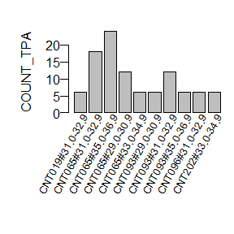

**plot**

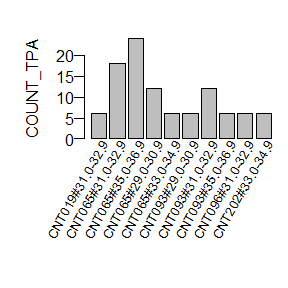

```r
names(treedomDIACNTs)
```

**output**

```
## [1] "tdomdat"      "tdomdat.prop" "tdomdat.pres" "tdomvarlut"   "tdomlst"
## [6] "tdomtotnm"
```

```r
tdomdat.pres <- treedomDIACNTs$tdomdat.pres
tdomdat.prop <- treedomDIACNTs$tdomdat.prop

head(tdomdat.pres)
```

**output**

```
##               CN INVYR STATECD CYCLE UNITCD COUNTYCD  PLOT LON_PUBLIC
## 1 40404728010690  2013      56     3      2        1 86688  -105.9625
## 2 40404729010690  2011      56     3      2        1 84596  -105.7277
## 3 40404730010690  2013      56     3      2        1 88993  -105.6679
## 4 40404731010690  2012      56     3      2        1 82340  -106.0313
## 5 40404733010690  2012      56     3      2        1 82869  -105.8509
## 6 40404734010690  2013      56     3      2        1 83304  -106.0363
##   LAT_PUBLIC MEASYEAR RDDISTCD NF_SAMPLING_STATUS_CD PLOT_STATUS_CD
## 1   42.41013     2013       NA                     0              2
## 2   42.40928     2011        1                     0              1
## 3   42.40953     2013        6                     0              1
## 4   42.35599     2012       NA                     0              2
## 5   42.31655     2012       NA                     0              2
## 6   42.26546     2013       NA                     0              2
##   NF_PLOT_STATUS_CD NBRCND NBRCNDSAMP NBRCNDFOR CCLIVEPLT        FORNONSAMP
```

[output cut: 27 more lines]